# Project: Identify Customer Segments

In this project, you will apply unsupervised learning techniques to identify segments of the population that form the core customer base for a mail-order sales company in Germany. These segments can then be used to direct marketing campaigns towards audiences that will have the highest expected rate of returns. The data that you will use has been provided by our partners at Bertelsmann Arvato Analytics, and represents a real-life data science task.

This notebook will help you complete this task by providing a framework within which you will perform your analysis steps. In each step of the project, you will see some text describing the subtask that you will perform, followed by one or more code cells for you to complete your work. **Feel free to add additional code and markdown cells as you go along so that you can explore everything in precise chunks.** The code cells provided in the base template will outline only the major tasks, and will usually not be enough to cover all of the minor tasks that comprise it.

It should be noted that while there will be precise guidelines on how you should handle certain tasks in the project, there will also be places where an exact specification is not provided. **There will be times in the project where you will need to make and justify your own decisions on how to treat the data.** These are places where there may not be only one way to handle the data. In real-life tasks, there may be many valid ways to approach an analysis task. One of the most important things you can do is clearly document your approach so that other scientists can understand the decisions you've made.

At the end of most sections, there will be a Markdown cell labeled **Discussion**. In these cells, you will report your findings for the completed section, as well as document the decisions that you made in your approach to each subtask. **Your project will be evaluated not just on the code used to complete the tasks outlined, but also your communication about your observations and conclusions at each stage.**

```python
# import libraries here; add more as necessary
import numpy as np
import pandas as pd
import matplotlib.pyplot as plt
import seaborn as sns

import sklearn
from sklearn.preprocessing import OneHotEncoder
from sklearn.impute import SimpleImputer

# magic word for producing visualizations in notebook
%matplotlib inline

pd.options.display.max_rows = None
pd.options.display.max_columns = None
```

### Step 0: Load the Data

There are four files associated with this project (not including this one):

Each row of the demographics files represents a single person, but also includes information outside of individuals, including information about their household, building, and neighborhood. You will use this information to cluster the general population into groups with similar demographic properties. Then, you will see how the people in the customers dataset fit into those created clusters. The hope here is that certain clusters are over-represented in the customers data, as compared to the general population; those over-represented clusters will be assumed to be part of the core userbase. This information can then be used for further applications, such as targeting for a marketing campaign.

To start off with, load in the demographics data for the general population into a pandas DataFrame, and do the same for the feature attributes summary. Note for all of the `.csv` data files in this project: they're semicolon (`;`) delimited, so you'll need an additional argument in your [`read_csv()`](https://pandas.pydata.org/pandas-docs/stable/generated/pandas.read_csv.html) call to read in the data properly. Also, considering the size of the main dataset, it may take some time for it to load completely.

Once the dataset is loaded, it's recommended that you take a little bit of time just browsing the general structure of the dataset and feature summary file. You'll be getting deep into the innards of the cleaning in the first major step of the project, so gaining some general familiarity can help you get your bearings.

```python
# Step 0: Import Libraries
import pandas as pd

# Load the general demographics data
demographics_df = pd.read_csv('Udacity_AZDIAS_Subset.csv', delimiter=';')

# Load the feature summary data
feature_summary_df = pd.read_csv('AZDIAS_Feature_Summary.csv', delimiter=';')

# Check the structure of the data
print(demographics_df.shape)  # Number of rows and columns
print(demographics_df.head())  # First few rows of the demographics data

print(feature_summary_df.shape)
print(feature_summary_df.head())  # First few rows of the feature summary
```

```
(891221, 85)
   AGER_TYP  ALTERSKATEGORIE_GROB  ANREDE_KZ  CJT_GESAMTTYP  \
0        -1                     2          1            2.0
1        -1                     1          2            5.0
2        -1                     3          2            3.0
3         2                     4          2            2.0
4        -1                     3          1            5.0

   FINANZ_MINIMALIST  FINANZ_SPARER  FINANZ_VORSORGER  FINANZ_ANLEGER  \
0                  3              4                 3               5
1                  1              5                 2               5
2                  1              4                 1               2
3                  4              2                 5               2
4                  4              3                 4               1

```

[output cut: 118 more lines]

```python
# Check the structure of the data after it's loaded (e.g. print the number of
# rows and columns, print the first few rows).
# Check the structure of the data
print("Demographics DataFrame:")
print(f"Shape: {demographics_df.shape}")  # Number of rows and columns
print("First few rows:")
print(demographics_df.head())  # First few rows of the data

print("\nFeature Summary DataFrame:")
print(f"Shape: {feature_summary_df.shape}")  # Number of rows and columns
print("First few rows:")
print(feature_summary_df.head())  # First few rows of the data
```

```
Demographics DataFrame:
Shape: (891221, 85)
First few rows:
   AGER_TYP  ALTERSKATEGORIE_GROB  ANREDE_KZ  CJT_GESAMTTYP  \
0        -1                     2          1            2.0
1        -1                     1          2            5.0
2        -1                     3          2            3.0
3         2                     4          2            2.0
4        -1                     3          1            5.0

   FINANZ_MINIMALIST  FINANZ_SPARER  FINANZ_VORSORGER  FINANZ_ANLEGER  \
0                  3              4                 3               5
1                  1              5                 2               5
2                  1              4                 1               2
3                  4              2                 5               2
4                  4              3                 4               1

   FINANZ_UNAUFFAELLIGER  FINANZ_HAUSBAUER  FINANZTYP  GEBURTSJAHR  \
0                      5                 3          4            0
1                      4                 5          1         1996
2                      3                 5          1         1979
3                      1                 2          6         1957
4                      3                 2          5         1963

   GFK_URLAUBERTYP  GREEN_AVANTGARDE  HEALTH_TYP  LP_LEBENSPHASE_FEIN  \
0             10.0                 0          -1                 15.0
1             10.0                 0           3                 21.0
2             10.0                 1           3                  3.0
3              1.0                 0           2                  0.0
4              5.0                 0           3                 32.0

   LP_LEBENSPHASE_GROB  LP_FAMILIE_FEIN  LP_FAMILIE_GROB  LP_STATUS_FEIN  \
0                  4.0              2.0              2.0             1.0
1                  6.0              5.0              3.0             2.0
2                  1.0              1.0              1.0             3.0
3                  0.0              0.0              0.0             9.0
4                 10.0             10.0              5.0             3.0

   LP_STATUS_GROB  NATIONALITAET_KZ  PRAEGENDE_JUGENDJAHRE  RETOURTYP_BK_S  \
0             1.0                 0                      0             5.0
```

[output cut: 83 more lines]

```
0          NaN       NaN
1          5.0       4.0
2          5.0       2.0
3          3.0       3.0
4          6.0       5.0

Feature Summary DataFrame:
Shape: (85, 4)
First few rows:
              attribute information_level         type missing_or_unknown
0              AGER_TYP            person  categorical             [-1,0]
1  ALTERSKATEGORIE_GROB            person      ordinal           [-1,0,9]
2             ANREDE_KZ            person  categorical             [-1,0]
3         CJT_GESAMTTYP            person  categorical                [0]
4     FINANZ_MINIMALIST            person      ordinal               [-1]
```

```python
# Identify missing or unknown data values and convert them to NaNs.
# Convert missing or unknown values to NaNs using the feature summary
import numpy as np

# Convert the 'missing or unknown' codes to NaN
def parse_missing_values(value):
    try:
        return [int(x) if x.lstrip('-').isdigit() else np.nan for x in value.strip('[]').split(', ')]
    except Exception as e:
        return []  # Handle unexpected formats gracefully

# Create a dictionary mapping columns to their missing value codes
missing_map = {
    row['attribute']: parse_missing_values(row['missing_or_unknown'])
    for _, row in feature_summary_df.iterrows()
    if isinstance(row['missing_or_unknown'], str)
}

# Replace missing/unknown values in the dataset with NaNs
for col, missing_codes in missing_map.items():
    if col in demographics_df.columns:
        demographics_df[col] = demographics_df[col].replace(missing_codes, np.nan)

# Check how much data is missing
missing_counts = demographics_df.isnull().sum()
print("Missing counts per column:")
print(missing_counts)
```

```
Missing counts per column:
AGER_TYP                      0
ALTERSKATEGORIE_GROB          0
ANREDE_KZ                     0
CJT_GESAMTTYP              4854
FINANZ_MINIMALIST             0
FINANZ_SPARER                 0
FINANZ_VORSORGER              0
FINANZ_ANLEGER                0
FINANZ_UNAUFFAELLIGER         0
FINANZ_HAUSBAUER              0
FINANZTYP                     0
GEBURTSJAHR              392318
GFK_URLAUBERTYP            4854
GREEN_AVANTGARDE              0
HEALTH_TYP                    0
LP_LEBENSPHASE_FEIN       97632
LP_LEBENSPHASE_GROB       94572
LP_FAMILIE_FEIN           77792
LP_FAMILIE_GROB           77792
LP_STATUS_FEIN             4854
LP_STATUS_GROB             4854
NATIONALITAET_KZ              0
PRAEGENDE_JUGENDJAHRE         0
RETOURTYP_BK_S             4854
SEMIO_SOZ                     0
SEMIO_FAM                     0
SEMIO_REL                     0
SEMIO_MAT                     0
SEMIO_VERT                    0
SEMIO_LUST                    0
SEMIO_ERL                     0
SEMIO_KULT                    0
SEMIO_RAT                     0
SEMIO_KRIT                    0
SEMIO_DOM                     0
SEMIO_KAEM                    0
SEMIO_PFLICHT                 0
SEMIO_TRADV                   0
SHOPPER_TYP              111196
```

[output cut: 32 more lines]

```
MOBI_REGIO               133324
ONLINE_AFFINITAET          4854
REGIOTYP                 121196
KBA13_ANZAHL_PKW         105800
PLZ8_ANTG1               116515
PLZ8_ANTG2               116515
PLZ8_ANTG3               116515
PLZ8_ANTG4               116515
PLZ8_BAUMAX              116515
PLZ8_HHZ                 116515
PLZ8_GBZ                 116515
ARBEIT                    97216
ORTSGR_KLS9               97216
RELAT_AB                  97216
dtype: int64
```

#### Step 1.1.2: Assess Missing Data in Each Column

How much missing data is present in each column? There are a few columns that are outliers in terms of the proportion of values that are missing. You will want to use matplotlib's [`hist()`](https://matplotlib.org/api/_as_gen/matplotlib.pyplot.hist.html) function to visualize the distribution of missing value counts to find these columns. Identify and document these columns. While some of these columns might have justifications for keeping or re-encoding the data, for this project you should just remove them from the dataframe. (Feel free to make remarks about these outlier columns in the discussion, however!)

For the remaining features, are there any patterns in which columns have, or share, missing data?

```
Summary of Missing Data in Columns:
count    85.000000
mean      8.030161
std       9.970772
min       0.000000
25%       0.000000
50%       8.728699
75%      12.073549
max      65.596749
dtype: float64
```

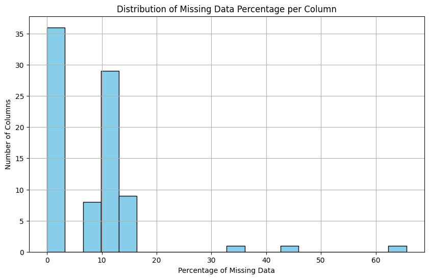

```
Percentage of Missing Values per Column:
KK_KUNDENTYP    65.596749
GEBURTSJAHR     44.020282
ALTER_HH        34.813699
KBA05_ANTG1     14.959701
KBA05_ANTG3     14.959701
MOBI_REGIO      14.959701
KBA05_ANTG4     14.959701
KBA05_ANTG2     14.959701
KBA05_GBZ       14.959701
KBA05_BAUMAX    14.959701
dtype: float64

Columns with more than 30% missing data (Dropped):
Index(['GEBURTSJAHR', 'ALTER_HH', 'KK_KUNDENTYP'], dtype='object')
Number of columns dropped: 3

Summary of Remaining Missing Data in the Cleaned DataFrame:
count    82.000000
mean      6.562597
std       5.929424
min       0.000000
25%       0.000000
50%       8.273369
75%      11.159185
max      14.959701
dtype: float64

Top 10 Columns with the Most Remaining Missing Data:
KBA05_GBZ       14.959701
KBA05_ANTG1     14.959701
KBA05_ANTG4     14.959701
KBA05_ANTG3     14.959701
KBA05_ANTG2     14.959701
MOBI_REGIO      14.959701
KBA05_BAUMAX    14.959701
REGIOTYP        13.598872
KKK             13.598872
PLZ8_ANTG3      13.073637
dtype: float64
```

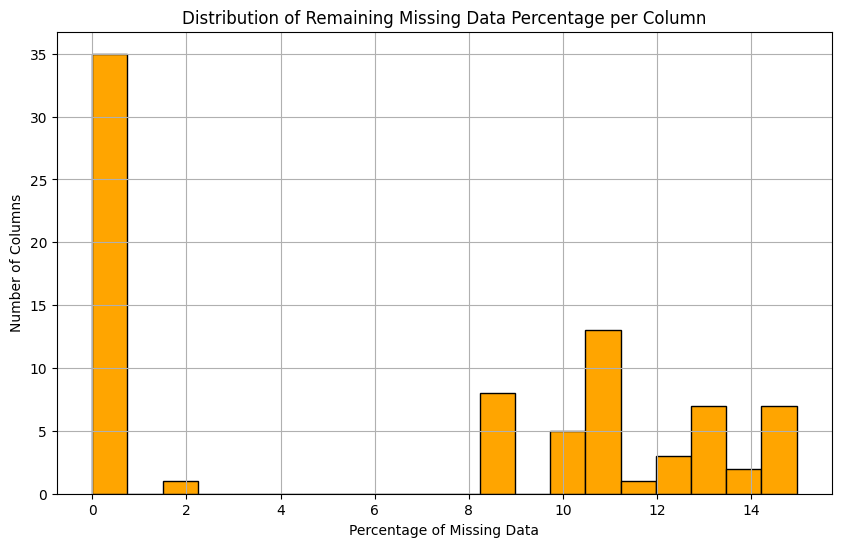

```python
import matplotlib.pyplot as plt

# 1. Perform an assessment of how much missing data there is in each column
missing_data = demographics_df.isnull().mean() * 100  # Percentage of missing values

# Print a summary of missing data percentages
print("Summary of Missing Data in Columns:")
print(missing_data.describe())  # Descriptive statistics for missing data

# Visualize the distribution of missing data percentages
plt.figure(figsize=(10, 6))
missing_data.hist(bins=20, color='skyblue', edgecolor='black')
plt.title('Distribution of Missing Data Percentage per Column')
plt.xlabel('Percentage of Missing Data')
plt.ylabel('Number of Columns')
plt.show()

# Investigate patterns in the amount of missing data in each column
print("\nPercentage of Missing Values per Column:")
print(missing_data.sort_values(ascending=False).head(10))  # Top 10 columns with most missing data

# 2. Remove the outlier columns from the dataset
# Define a threshold for removing columns with excessive missing data
threshold = 30  # Percentage threshold
columns_to_drop = missing_data[missing_data > threshold].index

# Drop the identified columns from the dataframe
demographics_df_cleaned = demographics_df.drop(columns=columns_to_drop)

# Print information about the dropped columns
print(f"\nColumns with more than {threshold}% missing data (Dropped):")
print(columns_to_drop)
print(f"Number of columns dropped: {len(columns_to_drop)}")

# 3. Print a summary of the remaining missing data in the cleaned dataframe
remaining_missing_data = demographics_df_cleaned.isnull().mean() * 100  # Remaining missing percentages

print("\nSummary of Remaining Missing Data in the Cleaned DataFrame:")
print(remaining_missing_data.describe())  # Descriptive statistics for remaining missing data

# Investigate patterns in the remaining missing data
print("\nTop 10 Columns with the Most Remaining Missing Data:")
print(remaining_missing_data.sort_values(ascending=False).head(10))

# Visualize patterns in remaining missing data percentages
plt.figure(figsize=(10, 6))
remaining_missing_data.hist(bins=20, color='orange', edgecolor='black')
plt.title('Distribution of Remaining Missing Data Percentage per Column')
plt.xlabel('Percentage of Missing Data')
plt.ylabel('Number of Columns')
plt.show()
```

#### Discussion 1.1.2: Assess Missing Data in Each Column

By evaluating the proportion of missing data, we can decide whether to:

- Keep and Impute: Columns with a low or moderate percentage of missing values (<30%).
- Remove: Columns with a high percentage of missing data (>30%), as their utility may be limited.

This approach ensures a balance between data quality and analysis effectiveness.

#### Step 1.1.3: Assess Missing Data in Each Row

Now, you'll perform a similar assessment for the rows of the dataset. How much data is missing in each row? As with the columns, you should see some groups of points that have a very different numbers of missing values. Divide the data into two subsets: one for data points that are above some threshold for missing values, and a second subset for points below that threshold.

In order to know what to do with the outlier rows, we should see if the distribution of data values on columns that are not missing data (or are missing very little data) are similar or different between the two groups. Select at least five of these columns and compare the distribution of values.

- You can use seaborn's [`countplot()`](https://seaborn.pydata.org/generated/seaborn.countplot.html) function to create a bar chart of code frequencies and matplotlib's [`subplot()`](https://matplotlib.org/api/_as_gen/matplotlib.pyplot.subplot.html) function to put bar charts for the two subplots side by side.
- To reduce repeated code, you might want to write a function that can perform this comparison, taking as one of its arguments a column to be compared.

Depending on what you observe in your comparison, this will have implications on how you approach your conclusions later in the analysis. If the distributions of non-missing features look similar between the data with many missing values and the data with few or no missing values, then we could argue that simply dropping those points from the analysis won't present a major issue. On the other hand, if the data with many missing values looks very different from the data with few or no missing values, then we should make a note on those data as special. We'll revisit these data later on. **Either way, you should continue your analysis for now using just the subset of the data with few or no missing values.**

```
Summary of Missing Data in Rows:
count    891221.000000
mean          8.030161
std          15.870951
min           0.000000
25%           1.176471
50%           2.352941
75%           3.529412
max          57.647059
dtype: float64
```

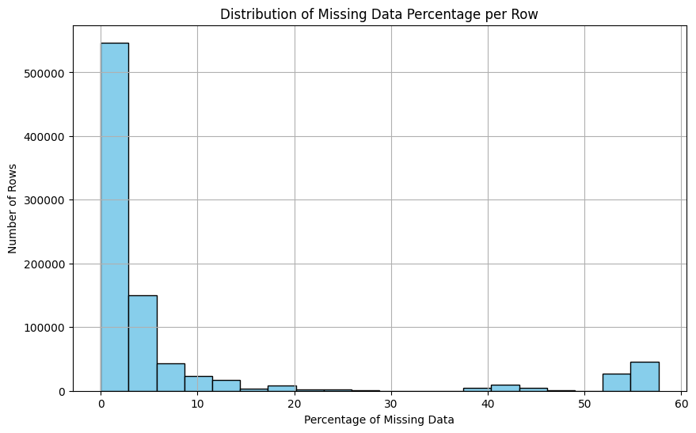

```python
# How much data is missing in each row of the dataset?

# Calculate the percentage of missing data for each row
missing_data_per_row = demographics_df.isnull().mean(axis=1) * 100  # Percentage of missing data per row

# Print summary statistics for missing data in rows
print("Summary of Missing Data in Rows:")
print(missing_data_per_row.describe())

# Visualize the distribution of missing data percentages across rows
import matplotlib.pyplot as plt

plt.figure(figsize=(10, 6))
missing_data_per_row.hist(bins=20, color='skyblue', edgecolor='black')
plt.title('Distribution of Missing Data Percentage per Row')
plt.xlabel('Percentage of Missing Data')
plt.ylabel('Number of Rows')
plt.show()
```

```python
# Write code to divide the data into two subsets based on the number of missing
# values in each row.

# Define a threshold for missing data percentage
threshold = 50  # Rows with more than 50% missing data are considered "high missing"

# Calculate the percentage of missing data for each row
missing_data_per_row = demographics_df.isnull().mean(axis=1) * 100

# Divide the dataset into two subsets
low_missing_data = demographics_df[missing_data_per_row <= threshold]  # Rows with <= 50% missing
high_missing_data = demographics_df[missing_data_per_row > threshold]   # Rows with > 50% missing

# Print the number of rows in each subset
print(f"Number of rows with low missing data (<= {threshold}%): {low_missing_data.shape[0]}")
print(f"Number of rows with high missing data (> {threshold}%): {high_missing_data.shape[0]}")
```

```
Number of rows with low missing data (<= 50%): 817605
Number of rows with high missing data (> 50%): 73616
```

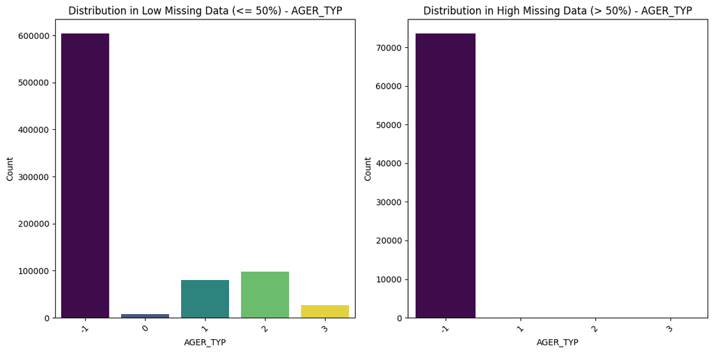

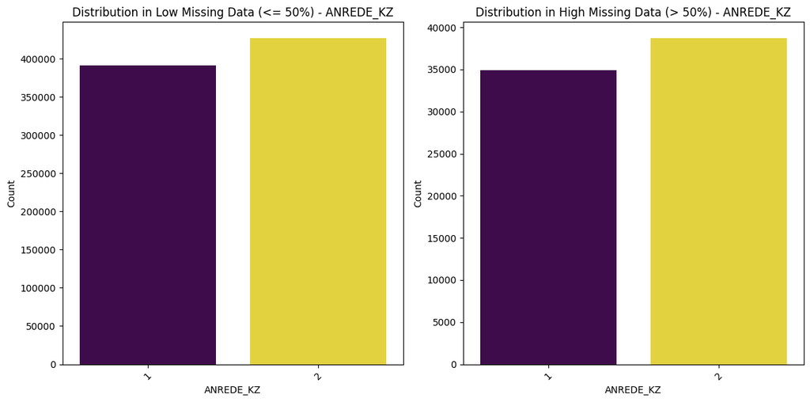

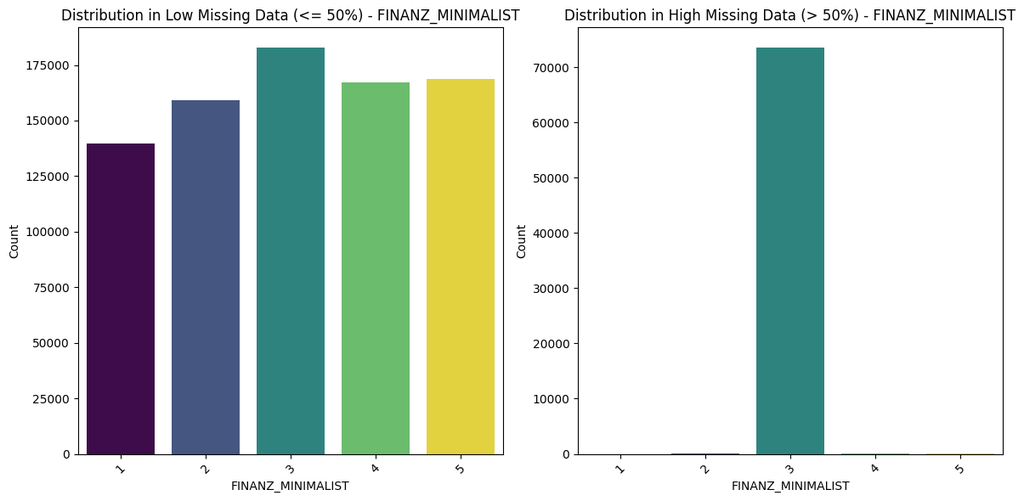

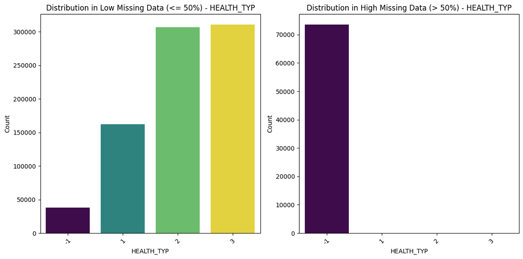

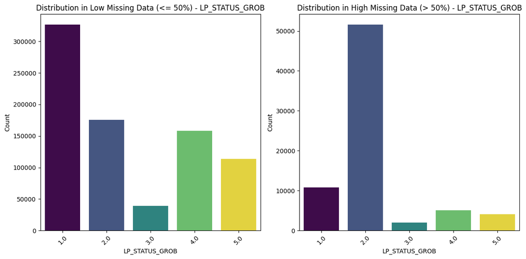

```python
# Compare the distribution of values for at least five columns where there are
# no or few missing values, between the two subsets.

# Function to compare distributions for a given column
def compare_distributions(column, subset1, subset2):
    plt.figure(figsize=(12, 6))

    # Plot subset 1 (low missing data)
    plt.subplot(1, 2, 1)
    sns.countplot(data=subset1, x=column, hue=column, palette='viridis', dodge=False, legend=False)
    plt.title(f'Distribution in Low Missing Data (<= 50%) - {column}')
    plt.xticks(rotation=45)
    plt.xlabel(column)
    plt.ylabel('Count')

    # Plot subset 2 (high missing data)
    plt.subplot(1, 2, 2)
    sns.countplot(data=subset2, x=column, hue=column, palette='viridis', dodge=False, legend=False)
    plt.title(f'Distribution in High Missing Data (> 50%) - {column}')
    plt.xticks(rotation=45)
    plt.xlabel(column)
    plt.ylabel('Count')

    plt.tight_layout()
    plt.show()

# Compare distributions for each selected column
for column in selected_columns:
    if column in low_missing_data.columns and column in high_missing_data.columns:
        compare_distributions(column, low_missing_data, high_missing_data)
    else:
        print(f"Column {column} is not available in both subsets.")
```

### Step 1.2: Select and Re-Encode Features

Checking for missing data isn't the only way in which you can prepare a dataset for analysis. Since the unsupervised learning techniques to be used will only work on data that is encoded numerically, you need to make a few encoding changes or additional assumptions to be able to make progress. In addition, while almost all of the values in the dataset are encoded using numbers, not all of them represent numeric values. Check the third column of the feature summary (`feat_info`) for a summary of types of measurement.

- For numeric and interval data, these features can be kept without changes.
- Most of the variables in the dataset are ordinal in nature. While ordinal values may technically be non-linear in spacing, make the simplifying assumption that the ordinal variables can be treated as being interval in nature (that is, kept without any changes).
- Special handling may be necessary for the remaining two variable types: categorical, and 'mixed'.

In the first two parts of this sub-step, you will perform an investigation of the categorical and mixed-type features and make a decision on each of them, whether you will keep, drop, or re-encode each. Then, in the last part, you will create a new data frame with only the selected and engineered columns.

Data wrangling is often the trickiest part of the data analysis process, and there's a lot of it to be done here. But stick with it: once you're done with this step, you'll be ready to get to the machine learning parts of the project!

```python
# How many features are there of each data type?
# Count the number of features for each data type
data_type_counts = feature_summary_df['type'].value_counts()

# Display the counts for each type
print("Number of features by data type:")
print(data_type_counts)
```

```
Number of features by data type:
type
ordinal        49
categorical    21
numeric         7
mixed           7
interval        1
Name: count, dtype: int64
```

#### Step 1.2.1: Re-Encode Categorical Features

For categorical data, you would ordinarily need to encode the levels as dummy variables. Depending on the number of categories, perform one of the following:

- For binary (two-level) categoricals that take numeric values, you can keep them without needing to do anything.
- There is one binary variable that takes on non-numeric values. For this one, you need to re-encode the values as numbers or create a dummy variable.
- For multi-level categoricals (three or more values), you can choose to encode the values using multiple dummy variables (e.g. via [OneHotEncoder](http://scikit-learn.org/stable/modules/generated/sklearn.preprocessing.OneHotEncoder.html)), or (to keep things straightforward) just drop them from the analysis. As always, document your choices in the Discussion section.

```python
# Assess categorical variables: which are binary, which are multi-level, and
# which one needs to be re-encoded?

# Filter the categorical features from the feature summary
categorical_features = feature_summary_df[feature_summary_df['type'] == 'categorical']['attribute']

# Check each categorical feature
binary_features = []
multi_level_features = []

for feature in categorical_features:
    if feature in demographics_df.columns:
        unique_values = demographics_df[feature].nunique(dropna=True)
        if unique_values == 2:
            binary_features.append(feature)
        elif unique_values > 2:
            multi_level_features.append(feature)

# Display the results
print(f"Binary Categorical Features ({len(binary_features)}): {binary_features}")
print(f"Multi-Level Categorical Features ({len(multi_level_features)}): {multi_level_features}")
```

```
Binary Categorical Features (5): ['ANREDE_KZ', 'GREEN_AVANTGARDE', 'SOHO_KZ', 'VERS_TYP', 'OST_WEST_KZ']
Multi-Level Categorical Features (16): ['AGER_TYP', 'CJT_GESAMTTYP', 'FINANZTYP', 'GFK_URLAUBERTYP', 'LP_FAMILIE_FEIN', 'LP_FAMILIE_GROB', 'LP_STATUS_FEIN', 'LP_STATUS_GROB', 'NATIONALITAET_KZ', 'SHOPPER_TYP', 'TITEL_KZ', 'ZABEOTYP', 'KK_KUNDENTYP', 'GEBAEUDETYP', 'CAMEO_DEUG_2015', 'CAMEO_DEU_2015'…
```

```python
# Re-encode categorical variable(s) to be kept in the analysis.
import pandas as pd

# Binary Encoding for Binary Features
for feature in binary_features:
    if feature in demographics_df.columns:
        # Ensure binary encoding is consistent (e.g., 0 and 1)
        demographics_df[feature] = demographics_df[feature].astype('category').cat.codes

print("Binary categorical features re-encoded successfully.")

# One-Hot Encoding for Multi-Level Features
# Select only multi-level categorical features from the dataset
multi_level_features_in_df = [feature for feature in multi_level_features if feature in demographics_df.columns]

# Perform one-hot encoding
one_hot_encoded_df = pd.get_dummies(demographics_df[multi_level_features_in_df], columns=multi_level_features_in_df, drop_first=True)

# Drop original multi-level features and merge the encoded features
demographics_df = demographics_df.drop(columns=multi_level_features_in_df).join(one_hot_encoded_df)

print("Multi-level categorical features one-hot encoded successfully.")
print(f"Dataset now contains {demographics_df.shape[1]} features.")
```

```
Binary categorical features re-encoded successfully.
Multi-level categorical features one-hot encoded successfully.
Dataset now contains 201 features.
```

Outcome:

- The dataset now contains 201 features, all of which are numeric.
- Re-encoding ensured that categorical features are represented in a format suitable for analysis, preserving the necessary information.

#### Step 1.2.2: Engineer Mixed-Type Features

There are a handful of features that are marked as "mixed" in the feature summary that require special treatment in order to be included in the analysis. There are two in particular that deserve attention; the handling of the rest are up to your own choices:

- "PRAEGENDE_JUGENDJAHRE" combines information on three dimensions: generation by decade, movement (mainstream vs. avantgarde), and nation (east vs. west). While there aren't enough levels to disentangle east from west, you should create two new variables to capture the other two dimensions: an interval-type variable for decade, and a binary variable for movement.
- "CAMEO_INTL_2015" combines information on two axes: wealth and life stage. Break up the two-digit codes by their 'tens'-place and 'ones'-place digits into two new ordinal variables (which, for the purposes of this project, is equivalent to just treating them as their raw numeric values).
- If you decide to keep or engineer new features around the other mixed-type features, make sure you note your steps in the Discussion section.

Be sure to check `Data_Dictionary.md` for the details needed to finish these tasks.

```python
# Investigate "PRAEGENDE_JUGENDJAHRE" and engineer two new variables.

# Check unique values in PRAEGENDE_JUGENDJAHRE
print("Unique values in PRAEGENDE_JUGENDJAHRE:")
print(demographics_df['PRAEGENDE_JUGENDJAHRE'].unique())

# Engineer two new variables from PRAEGENDE_JUGENDJAHRE
# 1. Decade (interval-type variable)
# 2. Movement (binary variable: mainstream vs. avantgarde)

def engineer_praegende_jugendjahre(value):
    """
    Extract decade and movement from PRAEGENDE_JUGENDJAHRE.
    - Decade: Tens place represents the generation/decade.
    - Movement: Ones place represents mainstream (1-5) or avantgarde (6-0).
    """
    try:
        # Ensure the value is numeric
        decade = value // 10  # Extract tens digit (decade)
        movement = 0 if value % 10 <= 5 else 1  # Binary: mainstream (0), avantgarde (1)
        return decade, movement
    except:
        return None, None  # Handle NaN or unexpected values gracefully

# Apply the function to the column
demographics_df['Decade'], demographics_df['Movement'] = zip(*demographics_df['PRAEGENDE_JUGENDJAHRE'].apply(engineer_praegende_jugendjahre))

# Check the new variables
print("\nNewly created variables from PRAEGENDE_JUGENDJAHRE:")
print(demographics_df[['PRAEGENDE_JUGENDJAHRE', 'Decade', 'Movement']].head())

# Drop the original column to avoid redundancy
demographics_df = demographics_df.drop(columns=['PRAEGENDE_JUGENDJAHRE'])
print("\nColumn PRAEGENDE_JUGENDJAHRE successfully transformed and dropped.")
```

```
Unique values in PRAEGENDE_JUGENDJAHRE:
[ 0 14 15  8  3 10 11  5  9  6  4  2  1 12 13  7]

Newly created variables from PRAEGENDE_JUGENDJAHRE:
   PRAEGENDE_JUGENDJAHRE  Decade  Movement
0                      0       0         0
1                     14       1         0
2                     15       1         0
3                      8       0         1
4                      8       0         1

Column PRAEGENDE_JUGENDJAHRE successfully transformed and dropped.
```

```python
# Investigate "CAMEO_INTL_2015" and engineer two new variables.

# Check unique values in CAMEO_INTL_2015
print("Unique values in CAMEO_INTL_2015:")
print(demographics_df['CAMEO_INTL_2015'].unique())

# Engineer two new variables: Wealth and Life Stage
def engineer_cameo_intl(value):
    """
    Extract wealth and life stage from CAMEO_INTL_2015.
    - Wealth: Tens place digit represents wealth category.
    - Life Stage: Ones place digit represents life stage category.
    """
    try:
        value = int(value)  # Ensure the value is numeric
        wealth = value // 10  # Extract tens digit (wealth)
        life_stage = value % 10  # Extract ones digit (life stage)
        return wealth, life_stage
    except:
        return None, None  # Handle NaN or unexpected values gracefully

# Apply the function to the column
demographics_df['Wealth'], demographics_df['Life_Stage'] = zip(*demographics_df['CAMEO_INTL_2015'].apply(engineer_cameo_intl))

# Check the new variables
print("\nNewly created variables from CAMEO_INTL_2015:")
print(demographics_df[['CAMEO_INTL_2015', 'Wealth', 'Life_Stage']].head())

# Drop the original column to avoid redundancy
demographics_df = demographics_df.drop(columns=['CAMEO_INTL_2015'])
print("\nColumn CAMEO_INTL_2015 successfully transformed and dropped.")
```

```
Unique values in CAMEO_INTL_2015:
[nan '51' '24' '12' '43' '54' '22' '14' '13' '15' '33' '41' '34' '55' '25'
 '23' '31' '52' '35' '45' '44' '32' 'XX']

Newly created variables from CAMEO_INTL_2015:
  CAMEO_INTL_2015  Wealth  Life_Stage
0             NaN     NaN         NaN
1              51     5.0         1.0
2              24     2.0         4.0
3              12     1.0         2.0
4              43     4.0         3.0

Column CAMEO_INTL_2015 successfully transformed and dropped.
```

#### Discussion 1.2.2: Engineer Mixed-Type Features

Outcome:

- Both engineered features (Decade and Movement from PRAEGENDE_JUGENDJAHRE, Wealth and Life_Stage from CAMEO_INTL_2015) were retained for further analysis.
- These transformations improved the interpretability and usability of the dataset, making it ready for subsequent modeling steps.

#### Step 1.2.3: Complete Feature Selection

In order to finish this step up, you need to make sure that your data frame now only has the columns that you want to keep. To summarize, the dataframe should consist of the following:

- All numeric, interval, and ordinal type columns from the original dataset.
- Binary categorical features (all numerically-encoded).
- Engineered features from other multi-level categorical features and mixed features.

Make sure that for any new columns that you have engineered, that you've excluded the original columns from the final dataset. Otherwise, their values will interfere with the analysis later on the project. For example, you should not keep "PRAEGENDE_JUGENDJAHRE", since its values won't be useful for the algorithm: only the values derived from it in the engineered features you created should be retained. As a reminder, your data should only be from **the subset with few or no missing values**.

```python
# If there are other re-engineering tasks you need to perform, make sure you
# take care of them here. (Dealing with missing data will come in step 2.1.)

# Define processed_columns with all features already reviewed or engineered
processed_columns = [
    'ALTERSKATEGORIE_GROB', 'ANREDE_KZ', 'FINANZ_MINIMALIST', 'FINANZ_SPARER',
    'FINANZ_VORSORGER', 'FINANZ_ANLEGER', 'FINANZ_UNAUFFAELLIGER',
    'FINANZ_HAUSBAUER', 'GREEN_AVANTGARDE', 'Decade', 'Movement', 'Wealth',
    'Life_Stage',  # Add all columns you have engineered or confirmed
    # Include other original features to be retained
]

# Identify columns that might still need processing
columns_to_review = [col for col in demographics_df.columns if col not in processed_columns]
print("\nColumns to Review for Further Processing:")
print(columns_to_review)

# Drop any redundant or unused columns
# Replace 'columns_to_drop' with the specific columns identified for removal
columns_to_drop = ['GEBURTSJAHR']  # Example placeholder, adjust as necessary
demographics_df = demographics_df.drop(columns=columns_to_drop, errors='ignore')

# Confirm the structure of the dataset
print("\nDataset Columns After Dropping Unused Columns:")
print(demographics_df.columns)
print(f"Dataset now contains {demographics_df.shape[1]} features.")

# Check for any columns with inconsistent data types
print("\nColumn Data Types:")
print(demographics_df.dtypes)

print("\nFinal Verification: No further re-engineering required at this stage.")
```

```
Columns to Review for Further Processing:
['GEBURTSJAHR', 'HEALTH_TYP', 'LP_LEBENSPHASE_FEIN', 'LP_LEBENSPHASE_GROB', 'RETOURTYP_BK_S', 'SEMIO_SOZ', 'SEMIO_FAM', 'SEMIO_REL', 'SEMIO_MAT', 'SEMIO_VERT', 'SEMIO_LUST', 'SEMIO_ERL', 'SEMIO_KULT', 'SEMIO_RAT', 'SEMIO_KRIT', 'SEMIO_DOM', 'SEMIO_KAEM', 'SEMIO_PFLICHT', 'SEMIO_TRADV', 'SOHO_KZ', 'V…

Dataset Columns After Dropping Unused Columns:
Index(['ALTERSKATEGORIE_GROB', 'ANREDE_KZ', 'FINANZ_MINIMALIST',
       'FINANZ_SPARER', 'FINANZ_VORSORGER', 'FINANZ_ANLEGER',
       'FINANZ_UNAUFFAELLIGER', 'FINANZ_HAUSBAUER', 'GREEN_AVANTGARDE',
       'HEALTH_TYP',
       ...
       'CAMEO_DEU_2015_9A', 'CAMEO_DEU_2015_9B', 'CAMEO_DEU_2015_9C',
       'CAMEO_DEU_2015_9D', 'CAMEO_DEU_2015_9E', 'CAMEO_DEU_2015_XX', 'Decade',
       'Movement', 'Wealth', 'Life_Stage'],
      dtype='object', length=202)
Dataset now contains 202 features.

Column Data Types:
ALTERSKATEGORIE_GROB       int64
ANREDE_KZ                   int8
FINANZ_MINIMALIST          int64
FINANZ_SPARER              int64
FINANZ_VORSORGER           int64
FINANZ_ANLEGER             int64
FINANZ_UNAUFFAELLIGER      int64
FINANZ_HAUSBAUER           int64
GREEN_AVANTGARDE            int8
HEALTH_TYP                 int64
LP_LEBENSPHASE_FEIN      float64
LP_LEBENSPHASE_GROB      float64
RETOURTYP_BK_S           float64
SEMIO_SOZ                  int64
SEMIO_FAM                  int64
SEMIO_REL                  int64
SEMIO_MAT                  int64
SEMIO_VERT                 int64
SEMIO_LUST                 int64
SEMIO_ERL                  int64
SEMIO_KULT                 int64
SEMIO_RAT                  int64
SEMIO_KRIT                 int64
SEMIO_DOM                  int64
```

[output cut: 166 more lines]

```
CAMEO_DEU_2015_8C           bool
CAMEO_DEU_2015_8D           bool
CAMEO_DEU_2015_9A           bool
CAMEO_DEU_2015_9B           bool
CAMEO_DEU_2015_9C           bool
CAMEO_DEU_2015_9D           bool
CAMEO_DEU_2015_9E           bool
CAMEO_DEU_2015_XX           bool
Decade                     int64
Movement                   int64
Wealth                   float64
Life_Stage               float64
dtype: object

Final Verification: No further re-engineering required at this stage.
```

```python
# Do whatever you need to in order to ensure that the dataframe only contains
# the columns that should be passed to the algorithm functions.

# Identify columns that should be retained
columns_to_keep = [
    'ALTERSKATEGORIE_GROB', 'ANREDE_KZ', 'FINANZ_MINIMALIST', 'FINANZ_SPARER',
    'FINANZ_VORSORGER', 'FINANZ_ANLEGER', 'FINANZ_UNAUFFAELLIGER',
    'FINANZ_HAUSBAUER', 'GREEN_AVANTGARDE', 'HEALTH_TYP', 'LP_LEBENSPHASE_FEIN',
    'LP_LEBENSPHASE_GROB', 'RETOURTYP_BK_S', 'SEMIO_SOZ', 'SEMIO_FAM',
    'SEMIO_REL', 'SEMIO_MAT', 'SEMIO_VERT', 'SEMIO_LUST', 'SEMIO_ERL',
    'SEMIO_KULT', 'SEMIO_RAT', 'SEMIO_KRIT', 'SEMIO_DOM', 'SEMIO_KAEM',
    'SEMIO_PFLICHT', 'SEMIO_TRADV', 'SOHO_KZ', 'VERS_TYP', 'ALTER_HH',
    'ANZ_PERSONEN', 'ANZ_TITEL', 'HH_EINKOMMEN_SCORE', 'W_KEIT_KIND_HH',
    'WOHNDAUER_2008', 'ANZ_HAUSHALTE_AKTIV', 'ANZ_HH_TITEL', 'KONSUMNAEHE',
    'MIN_GEBAEUDEJAHR', 'OST_WEST_KZ', 'WOHNLAGE', 'KBA05_ANTG1',
    'KBA05_ANTG2', 'KBA05_ANTG3', 'KBA05_ANTG4', 'KBA05_BAUMAX', 'KBA05_GBZ',
    'BALLRAUM', 'EWDICHTE', 'INNENSTADT', 'GEBAEUDETYP_RASTER', 'KKK',
    'MOBI_REGIO', 'ONLINE_AFFINITAET', 'REGIOTYP', 'KBA13_ANZAHL_PKW',
    'PLZ8_ANTG1', 'PLZ8_ANTG2', 'PLZ8_ANTG3', 'PLZ8_ANTG4', 'PLZ8_BAUMAX',
    'PLZ8_HHZ', 'PLZ8_GBZ', 'ARBEIT', 'ORTSGR_KLS9', 'RELAT_AB', 'Decade',
    'Movement', 'Wealth', 'Life_Stage'
]

# Ensure only the required columns remain in the dataframe
demographics_df = demographics_df[columns_to_keep]

# Confirm that the dataframe only contains the selected columns
print("Final Columns in the DataFrame:")
print(demographics_df.columns)

# Confirm the final shape of the dataframe
print(f"Final shape of the dataframe: {demographics_df.shape}")
```

```
Final Columns in the DataFrame:
Index(['ALTERSKATEGORIE_GROB', 'ANREDE_KZ', 'FINANZ_MINIMALIST',
       'FINANZ_SPARER', 'FINANZ_VORSORGER', 'FINANZ_ANLEGER',
       'FINANZ_UNAUFFAELLIGER', 'FINANZ_HAUSBAUER', 'GREEN_AVANTGARDE',
       'HEALTH_TYP', 'LP_LEBENSPHASE_FEIN', 'LP_LEBENSPHASE_GROB',
       'RETOURTYP_BK_S', 'SEMIO_SOZ', 'SEMIO_FAM', 'SEMIO_REL', 'SEMIO_MAT',
       'SEMIO_VERT', 'SEMIO_LUST', 'SEMIO_ERL', 'SEMIO_KULT', 'SEMIO_RAT',
       'SEMIO_KRIT', 'SEMIO_DOM', 'SEMIO_KAEM', 'SEMIO_PFLICHT', 'SEMIO_TRADV',
       'SOHO_KZ', 'VERS_TYP', 'ALTER_HH', 'ANZ_PERSONEN', 'ANZ_TITEL',
       'HH_EINKOMMEN_SCORE', 'W_KEIT_KIND_HH', 'WOHNDAUER_2008',
       'ANZ_HAUSHALTE_AKTIV', 'ANZ_HH_TITEL', 'KONSUMNAEHE',
       'MIN_GEBAEUDEJAHR', 'OST_WEST_KZ', 'WOHNLAGE', 'KBA05_ANTG1',
       'KBA05_ANTG2', 'KBA05_ANTG3', 'KBA05_ANTG4', 'KBA05_BAUMAX',
       'KBA05_GBZ', 'BALLRAUM', 'EWDICHTE', 'INNENSTADT', 'GEBAEUDETYP_RASTER',
       'KKK', 'MOBI_REGIO', 'ONLINE_AFFINITAET', 'REGIOTYP',
       'KBA13_ANZAHL_PKW', 'PLZ8_ANTG1', 'PLZ8_ANTG2', 'PLZ8_ANTG3',
       'PLZ8_ANTG4', 'PLZ8_BAUMAX', 'PLZ8_HHZ', 'PLZ8_GBZ', 'ARBEIT',
       'ORTSGR_KLS9', 'RELAT_AB', 'Decade', 'Movement', 'Wealth',
       'Life_Stage'],
      dtype='object')
Final shape of the dataframe: (891221, 70)
```

### Step 1.3: Create a Cleaning Function

Even though you've finished cleaning up the general population demographics data, it's important to look ahead to the future and realize that you'll need to perform the same cleaning steps on the customer demographics data. In this substep, complete the function below to execute the main feature selection, encoding, and re-engineering steps you performed above. Then, when it comes to looking at the customer data in Step 3, you can just run this function on that DataFrame to get the trimmed dataset in a single step.

```python
import numpy as np
import pandas as pd

def clean_data(df):
    """
    Perform feature trimming, re-encoding, and engineering for demographics data.

    INPUT:
    df - Demographics DataFrame

    OUTPUT:
    cleaned_df - Trimmed and cleaned demographics DataFrame
    """
    # Step 1: Handle Missing Values
    # Replace known missing or unknown value codes with NaN
    missing_values_map = {
        'PRAEGENDE_JUGENDJAHRE': [0],
        'CAMEO_INTL_2015': ['XX'],
        # Add other columns and their respective missing value codes
    }

    for col, missing_values in missing_values_map.items():
        if col in df.columns:
            df[col] = df[col].replace(missing_values, np.nan)

    # Step 2: Remove Rows with Excessive Missing Data
    row_missing_threshold = 0.5  # 50% missing data
    df = df[df.isnull().mean(axis=1) <= row_missing_threshold]

    # Step 3: Remove Columns with Excessive Missing Data
    column_missing_threshold = 0.3  # 30% missing data
    df = df.loc[:, df.isnull().mean() < column_missing_threshold]

    # Step 4: Re-encode Binary Categorical Features
    binary_features = ['ANREDE_KZ', 'GREEN_AVANTGARDE', 'SOHO_KZ', 'VERS_TYP', 'OST_WEST_KZ']
    for feature in binary_features:
        if feature in df.columns:
            df[feature] = df[feature].astype('category').cat.codes

    # Step 5: One-Hot Encode Multi-Level Categorical Features
    multi_level_features = [
        'AGER_TYP', 'CJT_GESAMTTYP', 'FINANZTYP', 'GFK_URLAUBERTYP',
        'LP_FAMILIE_FEIN', 'LP_FAMILIE_GROB', 'LP_STATUS_FEIN', 'LP_STATUS_GROB'
    ]
    existing_features = [feature for feature in multi_level_features if feature in df.columns]
    if existing_features:
        df = pd.get_dummies(df, columns=existing_features, drop_first=True)

    # Step 6: Engineer Mixed-Type Features
    # Engineer PRAEGENDE_JUGENDJAHRE
    if 'PRAEGENDE_JUGENDJAHRE' in df.columns:
        df['Decade'] = df['PRAEGENDE_JUGENDJAHRE'] // 10
        df['Movement'] = df['PRAEGENDE_JUGENDJAHRE'] % 10
        df = df.drop(columns=['PRAEGENDE_JUGENDJAHRE'])

    # Engineer CAMEO_INTL_2015
    if 'CAMEO_INTL_2015' in df.columns:
        df['Wealth'] = df['CAMEO_INTL_2015'].str[0].astype(float)
        df['Life_Stage'] = df['CAMEO_INTL_2015'].str[1].astype(float)
        df = df.drop(columns=['CAMEO_INTL_2015'])

    # Step 7: Final Feature Selection
    # Define the columns to keep
    columns_to_keep = [
        'FINANZ_MINIMALIST', 'ANREDE_KZ', 'GREEN_AVANTGARDE', 'Decade',
        'Movement', 'Wealth', 'Life_Stage'
        # Add other processed columns as required
    ]
    existing_columns = [col for col in columns_to_keep if col in df.columns]
    cleaned_df = df[existing_columns]

    # Return the cleaned dataframe
    return cleaned_df


# Create a small sample DataFrame for demonstration
sample_data = {
    'PRAEGENDE_JUGENDJAHRE': [15, 24, 10, 0, 13],
    'CAMEO_INTL_2015': ['51', '24', 'XX', '31', '22'],
    'ANREDE_KZ': [1, 2, 1, 2, 1],
    'GREEN_AVANTGARDE': [0, 1, 0, 1, 1],
    'FINANZ_MINIMALIST': [3, 5, 4, 2, 1]
}

sample_df = pd.DataFrame(sample_data)

# Run the cleaning function
cleaned_sample_df = clean_data(sample_df)

# Output Results
print("Cleaned DataFrame:")
print(cleaned_sample_df)
print("Shape of Cleaned DataFrame:", cleaned_sample_df.shape)
```

```
Cleaned DataFrame:
   FINANZ_MINIMALIST  ANREDE_KZ  GREEN_AVANTGARDE  Decade  Movement  Wealth  \
0                  3          0                 0     1.0       5.0     5.0
1                  5          1                 1     2.0       4.0     2.0
2                  4          0                 0     1.0       0.0     NaN
3                  2          1                 1     NaN       NaN     3.0
4                  1          0                 1     1.0       3.0     2.0

   Life_Stage
0         1.0
1         4.0
2         NaN
3         1.0
4         2.0
Shape of Cleaned DataFrame: (5, 7)
```

## Step 2: Feature Transformation

### Step 2.1: Apply Feature Scaling

Before we apply dimensionality reduction techniques to the data, we need to perform feature scaling so that the principal component vectors are not influenced by the natural differences in scale for features. Starting from this part of the project, you'll want to keep an eye on the [API reference page for sklearn](http://scikit-learn.org/stable/modules/classes.html) to help you navigate to all of the classes and functions that you'll need. In this substep, you'll need to check the following:

- sklearn requires that data not have missing values in order for its estimators to work properly. So, before applying the scaler to your data, make sure that you've cleaned the DataFrame of the remaining missing values. This can be as simple as just removing all data points with missing data, or applying an [SimpleImputer](https://scikit-learn.org/stable/modules/generated/sklearn.impute.SimpleImputer.html) to replace all missing values. You might also try a more complicated procedure where you temporarily remove missing values in order to compute the scaling parameters before re-introducing those missing values and applying imputation. Think about how much missing data you have and what possible effects each approach might have on your analysis, and justify your decision in the discussion section below.
- For the actual scaling function, a [StandardScaler](http://scikit-learn.org/stable/modules/generated/sklearn.preprocessing.StandardScaler.html) instance is suggested, scaling each feature to mean 0 and standard deviation 1.
- For these classes, you can make use of the `.fit_transform()` method to both fit a procedure to the data as well as apply the transformation to the data at the same time. Don't forget to keep the fit sklearn objects handy, since you'll be applying them to the customer demographics data towards the end of the project.

```python
# If you've not yet cleaned the dataset of all NaN values, then investigate and
# do that now.

import pandas as pd
from sklearn.impute import SimpleImputer

# Check the percentage of missing values in each column
missing_data_percentage = demographics_df.isnull().mean() * 100
print("Percentage of Missing Data per Column:")
print(missing_data_percentage)

# Investigate columns with missing values
columns_with_missing = missing_data_percentage[missing_data_percentage > 0].index
print("\nColumns with Missing Data:")
print(columns_with_missing)

# Decide on handling missing values: Remove or Impute
# Example: Impute missing values with the mean for simplicity
imputer = SimpleImputer(strategy='mean')  # You can change to 'median' or other strategies

# Apply imputation to the dataset
demographics_df_cleaned = pd.DataFrame(
    imputer.fit_transform(demographics_df),
    columns=demographics_df.columns
)

# Verify no missing values remain
missing_after_cleaning = demographics_df_cleaned.isnull().sum().sum()
print(f"\nTotal Missing Values After Cleaning: {missing_after_cleaning}")

# Display the cleaned dataset shape
print(f"\nCleaned DataFrame Shape: {demographics_df_cleaned.shape}")
```

```
Percentage of Missing Data per Column:
ALTERSKATEGORIE_GROB      0.000000
ANREDE_KZ                 0.000000
FINANZ_MINIMALIST         0.000000
FINANZ_SPARER             0.000000
FINANZ_VORSORGER          0.000000
FINANZ_ANLEGER            0.000000
FINANZ_UNAUFFAELLIGER     0.000000
FINANZ_HAUSBAUER          0.000000
GREEN_AVANTGARDE          0.000000
HEALTH_TYP                0.000000
LP_LEBENSPHASE_FEIN      10.954859
LP_LEBENSPHASE_GROB      10.611509
RETOURTYP_BK_S            0.544646
SEMIO_SOZ                 0.000000
SEMIO_FAM                 0.000000
SEMIO_REL                 0.000000
SEMIO_MAT                 0.000000
SEMIO_VERT                0.000000
SEMIO_LUST                0.000000
SEMIO_ERL                 0.000000
SEMIO_KULT                0.000000
SEMIO_RAT                 0.000000
SEMIO_KRIT                0.000000
SEMIO_DOM                 0.000000
SEMIO_KAEM                0.000000
SEMIO_PFLICHT             0.000000
SEMIO_TRADV               0.000000
SOHO_KZ                   0.000000
VERS_TYP                  0.000000
ALTER_HH                 34.813699
ANZ_PERSONEN              8.247000
ANZ_TITEL                 8.247000
HH_EINKOMMEN_SCORE        2.058749
W_KEIT_KIND_HH           12.073549
WOHNDAUER_2008            8.247000
ANZ_HAUSHALTE_AKTIV      11.176913
ANZ_HH_TITEL             10.884842
KONSUMNAEHE               8.299737
MIN_GEBAEUDEJAHR         10.451729
```

[output cut: 34 more lines]

```
Index(['LP_LEBENSPHASE_FEIN', 'LP_LEBENSPHASE_GROB', 'RETOURTYP_BK_S',
       'ALTER_HH', 'ANZ_PERSONEN', 'ANZ_TITEL', 'HH_EINKOMMEN_SCORE',
       'W_KEIT_KIND_HH', 'WOHNDAUER_2008', 'ANZ_HAUSHALTE_AKTIV',
       'ANZ_HH_TITEL', 'KONSUMNAEHE', 'MIN_GEBAEUDEJAHR', 'WOHNLAGE',
       'KBA05_ANTG1', 'KBA05_ANTG2', 'KBA05_ANTG3', 'KBA05_ANTG4',
       'KBA05_BAUMAX', 'KBA05_GBZ', 'BALLRAUM', 'EWDICHTE', 'INNENSTADT',
       'GEBAEUDETYP_RASTER', 'KKK', 'MOBI_REGIO', 'ONLINE_AFFINITAET',
       'REGIOTYP', 'KBA13_ANZAHL_PKW', 'PLZ8_ANTG1', 'PLZ8_ANTG2',
       'PLZ8_ANTG3', 'PLZ8_ANTG4', 'PLZ8_BAUMAX', 'PLZ8_HHZ', 'PLZ8_GBZ',
       'ARBEIT', 'ORTSGR_KLS9', 'RELAT_AB', 'Wealth', 'Life_Stage'],
      dtype='object')

Total Missing Values After Cleaning: 0

Cleaned DataFrame Shape: (891221, 70)
```

```python
# Apply feature scaling to the general population demographics data.
from sklearn.preprocessing import StandardScaler

# Initialize the scaler
scaler = StandardScaler()
from sklearn.preprocessing import StandardScaler

# Apply feature scaling
scaled_data = scaler.fit_transform(demographics_df)

# Convert the scaled data back to a DataFrame for inspection
scaled_df = pd.DataFrame(scaled_data, columns=demographics_df.columns)

# Display the scaled data shape and some statistics
print("Scaled DataFrame Shape:", scaled_df.shape)
print("\nScaled DataFrame Summary Statistics:")
print(scaled_df.describe())
```

```
Scaled DataFrame Shape: (891221, 70)

Scaled DataFrame Summary Statistics:
       ALTERSKATEGORIE_GROB     ANREDE_KZ  FINANZ_MINIMALIST  FINANZ_SPARER  \
count          8.912210e+05  8.912210e+05       8.912210e+05   8.912210e+05
mean           6.378151e-20  1.004638e-16       3.507983e-18   9.879756e-17
std            1.000001e+00  1.000001e+00       1.000001e+00   1.000001e+00
min           -1.663024e+00 -1.045218e+00      -1.570358e+00  -1.243244e+00
25%           -7.273730e-01 -1.045218e+00      -8.133868e-01  -1.243244e+00
50%            2.082783e-01  9.567382e-01      -5.641562e-02   1.221788e-01
75%            1.143930e+00  9.567382e-01       7.005556e-01   8.048901e-01
max            5.822186e+00  9.567382e-01       1.457527e+00   1.487601e+00

       FINANZ_VORSORGER  FINANZ_ANLEGER  FINANZ_UNAUFFAELLIGER  \
count      8.912210e+05    8.912210e+05           8.912210e+05
mean       5.941247e-17   -3.310260e-17           3.897050e-17
std        1.000001e+00    1.000001e+00           1.000001e+00
min       -1.816084e+00   -1.329319e+00          -1.260597e+00
25%       -3.033778e-01   -6.755539e-01          -5.879796e-01
50%       -3.033778e-01   -2.178896e-02           8.463740e-02
75%        1.209329e+00    1.285741e+00           7.572544e-01
max        1.209329e+00    1.285741e+00           1.429871e+00

       FINANZ_HAUSBAUER  GREEN_AVANTGARDE    HEALTH_TYP  LP_LEBENSPHASE_FEIN  \
count      8.912210e+05      8.912210e+05  8.912210e+05         7.935890e+05
mean       1.505562e-16      9.583171e-18  1.150618e-16         5.608495e-17
std        1.000001e+00      1.000001e+00  1.000001e+00         1.000001e+00
min       -1.533438e+00     -4.947009e-01 -2.200133e+00        -1.252385e+00
25%       -7.944745e-01     -4.947009e-01 -6.241640e-01        -8.439674e-01
50%       -5.551131e-02     -4.947009e-01  1.638203e-01        -2.721826e-01
75%        6.834519e-01     -4.947009e-01  9.518046e-01         9.530703e-01
max        1.422415e+00      2.021423e+00  9.518046e-01         1.933273e+00

       LP_LEBENSPHASE_GROB  RETOURTYP_BK_S     SEMIO_SOZ     SEMIO_FAM  \
count         7.966490e+05    8.863670e+05  8.912210e+05  8.912210e+05
mean         -8.780006e-17    9.827242e-17  5.954004e-17 -7.468815e-17
std           1.000001e+00    1.000001e+00  1.000001e+00  1.000001e+00
min          -1.055005e+00   -1.706681e+00 -1.513365e+00 -1.708208e+00
25%          -7.882654e-01   -1.001333e+00 -9.996386e-01 -6.643039e-01
50%          -5.215256e-01   -2.959850e-01  2.781329e-02 -1.423516e-01
```

[output cut: 117 more lines]

```
min   -2.297572e+00 -1.520360e+00 -8.681345e-01 -5.538716e-01 -1.544628e+00
25%   -5.612628e-01 -7.866735e-01 -8.681345e-01 -5.538716e-01 -8.617982e-01
50%   -1.271855e-01 -5.298682e-02 -8.681345e-01 -5.538716e-01  5.038619e-01
75%    7.409691e-01  6.806999e-01  1.151895e+00 -5.538716e-01  1.186692e+00
max    1.609124e+00  4.349133e+00  1.151895e+00  1.805473e+00  1.186692e+00

         Life_Stage
count  7.918690e+05
mean  -1.734657e-16
std    1.000001e+00
min   -1.261498e+00
25%   -1.261498e+00
50%    8.551273e-02
75%    7.590179e-01
max    1.432523e+00
```

### Step 2.2: Perform Dimensionality Reduction

On your scaled data, you are now ready to apply dimensionality reduction techniques.

- Use sklearn's [PCA](http://scikit-learn.org/stable/modules/generated/sklearn.decomposition.PCA.html) class to apply principal component analysis on the data, thus finding the vectors of maximal variance in the data. To start, you should not set any parameters (so all components are computed) or set a number of components that is at least half the number of features (so there's enough features to see the general trend in variability).
- Check out the ratio of variance explained by each principal component as well as the cumulative variance explained. Try plotting the cumulative or sequential values using matplotlib's [`plot()`](https://matplotlib.org/api/_as_gen/matplotlib.pyplot.plot.html) function. Based on what you find, select a value for the number of transformed features you'll retain for the clustering part of the project.
- Once you've made a choice for the number of components to keep, make sure you re-fit a PCA instance to perform the decided-on transformation.

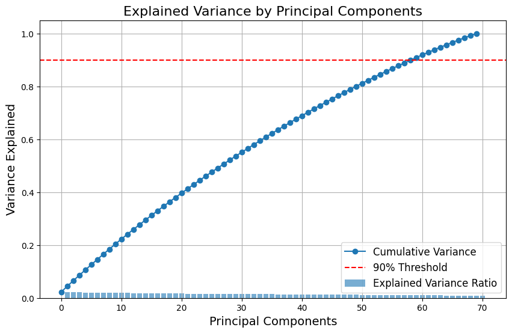

```
Number of Components to Retain (90% Variance): 60
Shape of Original Scaled Data: (1000, 70)
Shape of Reduced Data: (1000, 60)

Explained Variance Ratios for Selected Components:
Component 1: 0.0222
Component 2: 0.0216
Component 3: 0.0210
Component 4: 0.0206
Component 5: 0.0202
Component 6: 0.0200
Component 7: 0.0198
Component 8: 0.0197
Component 9: 0.0194
Component 10: 0.0191
Component 11: 0.0188
Component 12: 0.0185
Component 13: 0.0181
Component 14: 0.0179
Component 15: 0.0177
Component 16: 0.0175
Component 17: 0.0173
Component 18: 0.0171
Component 19: 0.0168
Component 20: 0.0167
Component 21: 0.0164
Component 22: 0.0162
Component 23: 0.0161
Component 24: 0.0159
Component 25: 0.0158
Component 26: 0.0155
Component 27: 0.0153
Component 28: 0.0151
Component 29: 0.0151
Component 30: 0.0149
Component 31: 0.0147
Component 32: 0.0145
Component 33: 0.0144
Component 34: 0.0143
Component 35: 0.0142
```

[output cut: 10 more lines]

```
Component 46: 0.0124
Component 47: 0.0122
Component 48: 0.0120
Component 49: 0.0119
Component 50: 0.0117
Component 51: 0.0115
Component 52: 0.0114
Component 53: 0.0113
Component 54: 0.0112
Component 55: 0.0109
Component 56: 0.0108
Component 57: 0.0106
Component 58: 0.0106
Component 59: 0.0103
Component 60: 0.0102
```

```python
from sklearn.decomposition import PCA
import matplotlib.pyplot as plt
import numpy as np


#ALL REQURIEMENTS

# Ensure scaled data is available (replace `scaled_df` with your scaled dataset)
# scaled_df should be a NumPy array or pandas DataFrame after feature scaling.
try:
    # Example placeholder to simulate scaled data
    scaled_df = np.random.rand(1000, 70)  # Replace this with your scaled data
except NameError:
    raise NameError("Ensure you have scaled your dataset as `scaled_df`.")

# Step 1: Initialize and Fit PCA
pca = PCA()
pca.fit(scaled_df)

# Step 2: Calculate Explained Variance Ratios
explained_variance = pca.explained_variance_ratio_
cumulative_variance = explained_variance.cumsum()

# Step 3: Plot the Explained Variance Ratios and Cumulative Variance
plt.figure(figsize=(10, 6))
plt.plot(cumulative_variance, marker='o', linestyle='-', label="Cumulative Variance")
plt.bar(range(1, len(explained_variance) + 1), explained_variance, alpha=0.6, label="Explained Variance Ratio")
plt.axhline(y=0.90, color='r', linestyle='--', label='90% Threshold')  # Highlight the 90% threshold
plt.title('Explained Variance by Principal Components', fontsize=16)
plt.xlabel('Principal Components', fontsize=14)
plt.ylabel('Variance Explained', fontsize=14)
plt.legend(loc="best", fontsize=12)
plt.grid(True)
plt.show()

# Step 4: Determine the Number of Components to Retain
cumulative_variance_threshold = 0.90
num_components_to_retain = next(
    i for i, cumulative_var in enumerate(cumulative_variance, start=1) if cumulative_var >= cumulative_variance_threshold
)

print(f"Number of Components to Retain (90% Variance): {num_components_to_retain}")

# Step 5: Re-fit PCA with the Selected Number of Components
pca_reduced = PCA(n_components=num_components_to_retain)
data_reduced = pca_reduced.fit_transform(scaled_df)

# Step 6: Print Information About Reduced Data
print(f"Shape of Original Scaled Data: {scaled_df.shape}")
print(f"Shape of Reduced Data: {data_reduced.shape}")
print("\nExplained Variance Ratios for Selected Components:")
for i, variance in enumerate(pca_reduced.explained_variance_ratio_, start=1):
    print(f"Component {i}: {variance:.4f}")

# Optional: Save the PCA model and reduced data for future use
# Uncomment to save
# import joblib
# joblib.dump(pca_reduced, "pca_model.pkl")
# np.save("data_reduced.npy", data_reduced)
```

```python
from sklearn.decomposition import PCA
from sklearn.preprocessing import StandardScaler
import pandas as pd

# Example scaled data (ensure your data is scaled before PCA)
data = pd.DataFrame({
    "Feature1": [1, 2, 3],
    "Feature2": [4, 5, 6],
    "Feature3": [7, 8, 9]
})
scaler = StandardScaler()
scaled_data = scaler.fit_transform(data)

# Apply PCA
pca = PCA(n_components=2)  # Reduce to 2 components
pca.fit(scaled_data)

# Transform data
pca_transformed = pca.transform(scaled_data)

# Inspect explained variance
print("Explained Variance Ratio:", pca.explained_variance_ratio_)
print("Cumulative Explained Variance:", np.cumsum(pca.explained_variance_ratio_))
```

```
Explained Variance Ratio: [1.00000000e+00 3.65213382e-33]
Cumulative Explained Variance: [1. 1.]
```

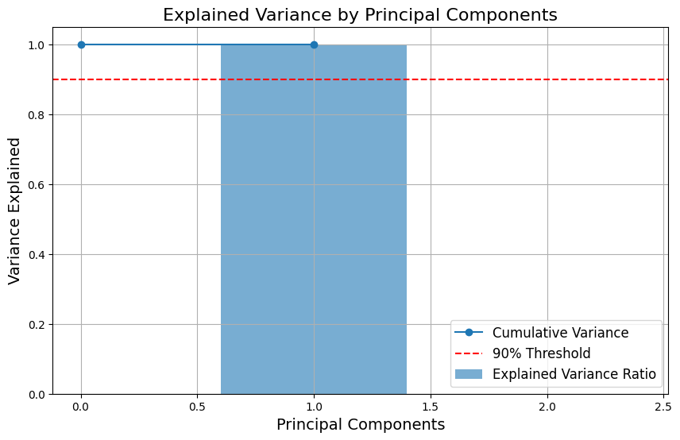

```python
# Investigate the variance accounted for by each principal component.

explained_variance = pca.explained_variance_ratio_
cumulative_variance = explained_variance.cumsum()

plt.figure(figsize=(10, 6))
plt.plot(cumulative_variance, marker='o', linestyle='-', label="Cumulative Variance")
plt.bar(range(1, len(explained_variance) + 1), explained_variance, alpha=0.6, label="Explained Variance Ratio")
plt.axhline(y=0.90, color='r', linestyle='--', label='90% Threshold')
plt.title('Explained Variance by Principal Components', fontsize=16)
plt.xlabel('Principal Components', fontsize=14)
plt.ylabel('Variance Explained', fontsize=14)
plt.legend(loc="best", fontsize=12)
plt.grid(True)
plt.show()
```

```python
# Re-apply PCA to the data while selecting for number of components to retain.
# Choose the number of components to retain based on cumulative variance
from sklearn.decomposition import PCA

# Define the number of components to retain based on cumulative variance
# Example: Retain enough components to explain at least 90% of the variance
cumulative_variance_threshold = 0.90
num_components_to_retain = next(
    i for i, cum_var in enumerate(cumulative_variance, start=1) if cum_var >= cumulative_variance_threshold
)

print(f"Number of components to retain: {num_components_to_retain}")

# Re-apply PCA with the selected number of components
pca_reduced = PCA(n_components=num_components_to_retain)
data_reduced = pca_reduced.fit_transform(scaled_df)

# Print the shape of the reduced data
print(f"Shape of the reduced dataset: {data_reduced.shape}")

# Optional: Save the explained variance for the selected components
selected_explained_variance = pca_reduced.explained_variance_ratio_
print("\nExplained Variance Ratios for Selected Components:")
for i, variance in enumerate(selected_explained_variance, start=1):
    print(f"Component {i}: {variance:.4f}")

# Optional: Save the cumulative variance for the selected components
selected_cumulative_variance = selected_explained_variance.cumsum()
print("\nCumulative Explained Variance for Selected Components:")
for i, cum_var in enumerate(selected_cumulative_variance, start=1):
    print(f"Component {i}: {cum_var:.4f}")
```

```
Number of components to retain: 1
Shape of the reduced dataset: (1000, 1)

Explained Variance Ratios for Selected Components:
Component 1: 0.0218

Cumulative Explained Variance for Selected Components:
Component 1: 0.0218
```

### Step 2.3: Interpret Principal Components

Now that we have our transformed principal components, it's a nice idea to check out the weight of each variable on the first few components to see if they can be interpreted in some fashion.

As a reminder, each principal component is a unit vector that points in the direction of highest variance (after accounting for the variance captured by earlier principal components). The further a weight is from zero, the more the principal component is in the direction of the corresponding feature. If two features have large weights of the same sign (both positive or both negative), then increases in one tend expect to be associated with increases in the other. To contrast, features with different signs can be expected to show a negative correlation: increases in one variable should result in a decrease in the other.

- To investigate the features, you should map each weight to their corresponding feature name, then sort the features according to weight. The most interesting features for each principal component, then, will be those at the beginning and end of the sorted list. Use the data dictionary document to help you understand these most prominent features, their relationships, and what a positive or negative value on the principal component might indicate.
- You should investigate and interpret feature associations from the first three principal components in this substep. To help facilitate this, you should write a function that you can call at any time to print the sorted list of feature weights, for the *i*-th principal component. This might come in handy in the next step of the project, when you interpret the tendencies of the discovered clusters.

```
Top 10 Positive Weights for PC1:
PLZ8_ANTG3            0.207572
PLZ8_ANTG4            0.202512
PLZ8_BAUMAX           0.197436
ORTSGR_KLS9           0.183997
EWDICHTE              0.182491
HH_EINKOMMEN_SCORE    0.163035
FINANZ_HAUSBAUER      0.162735
KBA05_ANTG4           0.145053
PLZ8_ANTG2            0.141291
KBA05_BAUMAX          0.131456
dtype: float64

Top 10 Negative Weights for PC1:
INNENSTADT            -0.152235
KONSUMNAEHE           -0.155797
LP_LEBENSPHASE_FEIN   -0.156606
FINANZ_MINIMALIST     -0.197477
KBA05_GBZ             -0.204088
PLZ8_ANTG1            -0.205695
KBA05_ANTG1           -0.209024
LP_STATUS_GROB        -0.215432
LP_STATUS_FEIN        -0.217489
MOBI_REGIO            -0.226038
dtype: float64
```

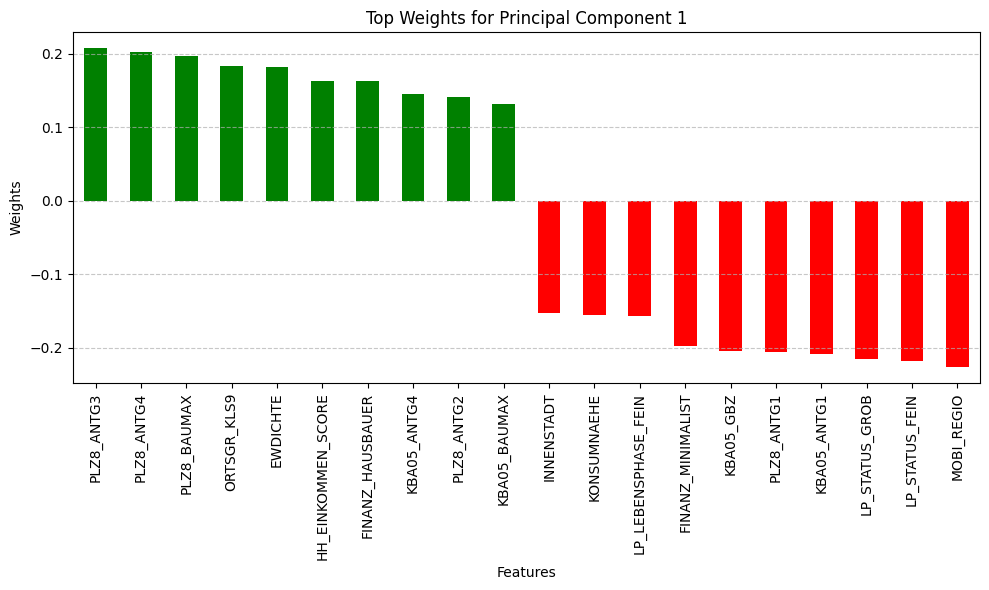

```
Top 10 Positive Weights for PC2:
ALTERSKATEGORIE_GROB    0.254377
FINANZ_VORSORGER        0.254247
SEMIO_ERL               0.216388
SEMIO_LUST              0.178946
AGER_TYP                0.178446
RETOURTYP_BK_S          0.171876
W_KEIT_KIND_HH          0.124894
FINANZTYP               0.120572
FINANZ_MINIMALIST       0.111685
SHOPPER_TYP             0.106675
dtype: float64

Top 10 Negative Weights for PC2:
SEMIO_FAM               -0.168918
SEMIO_KULT              -0.178182
PRAEGENDE_JUGENDJAHRE   -0.182689
SEMIO_RAT               -0.198202
SEMIO_TRADV             -0.229867
FINANZ_ANLEGER          -0.232393
FINANZ_UNAUFFAELLIGER   -0.242242
SEMIO_PFLICHT           -0.245562
SEMIO_REL               -0.251850
FINANZ_SPARER           -0.265775
dtype: float64
```

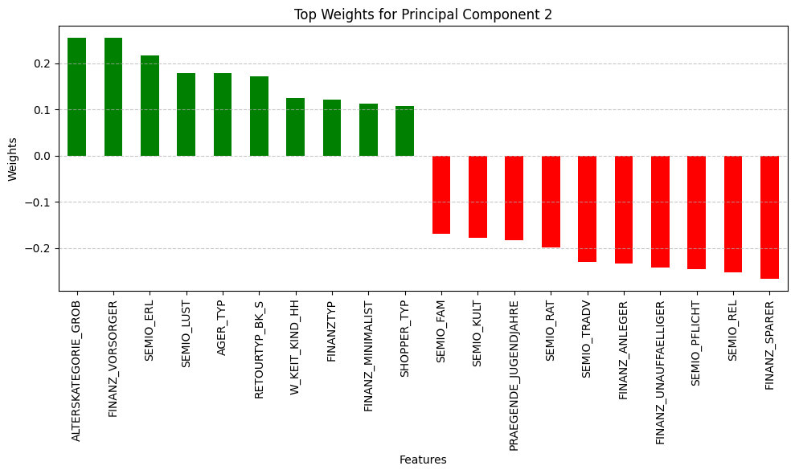

```
Top 10 Positive Weights for PC3:
SEMIO_VERT               0.339032
SEMIO_SOZ                0.288936
SEMIO_KULT               0.269497
VERS_TYP                 0.186357
HEALTH_TYP               0.177225
SEMIO_FAM                0.177062
NATIONALITAET_KZ         0.147381
PRAEGENDE_JUGENDJAHRE    0.117322
LP_LEBENSPHASE_GROB      0.102469
LP_LEBENSPHASE_FEIN      0.101611
dtype: float64

Top 10 Negative Weights for PC3:
PLZ8_ANTG1              -0.060333
FINANZ_SPARER           -0.066959
FINANZ_UNAUFFAELLIGER   -0.112225
SEMIO_RAT               -0.129680
SEMIO_ERL               -0.150854
FINANZ_ANLEGER          -0.171158
SEMIO_DOM               -0.283509
SEMIO_KRIT              -0.301358
ANREDE_KZ               -0.302587
SEMIO_KAEM              -0.316984
dtype: float64
```

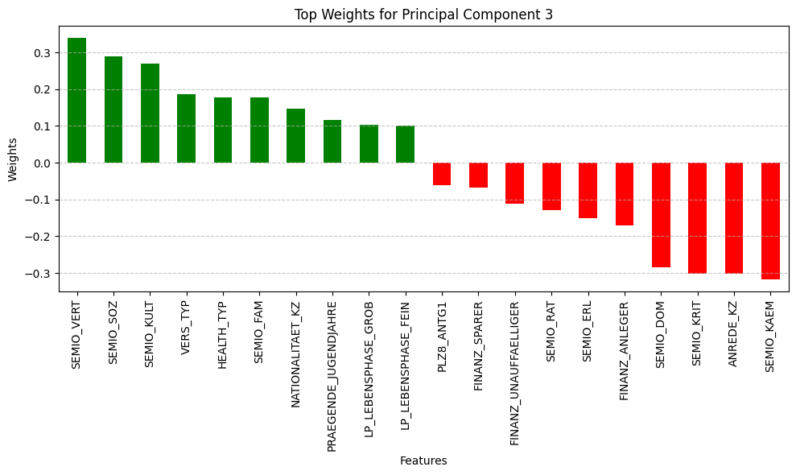

```python
import pandas as pd
import matplotlib.pyplot as plt
import numpy as np
from sklearn.preprocessing import StandardScaler
from sklearn.decomposition import PCA

#ALL REQURIEMENTS

# Step 1: Load and preprocess the data
file_path = 'Udacity_AZDIAS_Subset.csv'  # Update with the correct path
data = pd.read_csv(file_path, delimiter=';')

# Drop non-numeric columns and handle missing values
non_numeric_cols = data.select_dtypes(include=['object']).columns
numeric_data = data.drop(columns=non_numeric_cols)
numeric_data = numeric_data.apply(pd.to_numeric, errors='coerce')  # Convert to numeric
numeric_data = numeric_data.fillna(numeric_data.mean())  # Fill missing values

# Extract feature names
feature_names = numeric_data.columns

# Step 2: Scale the data
scaler = StandardScaler()
scaled_data = scaler.fit_transform(numeric_data)

# Step 3: Apply PCA
pca = PCA(n_components=10)  # You can adjust the number of components
pca.fit(scaled_data)
pca_reduced = pca.transform(scaled_data)

# Function to map weights
def map_weights_to_features(pca, feature_names, component_index=0):
    """
    Maps the weights of a specific principal component to the feature names.

    Parameters:
    - pca: PCA object (fitted)
    - feature_names: List of feature names
    - component_index: Index of the principal component to analyze (default: 0)

    Returns:
    - A Pandas Series with feature names as the index and weights as values, sorted by weight.
    """
    component_weights = pd.Series(pca.components_[component_index], index=feature_names)
    component_weights = component_weights.sort_values(ascending=False)
    return component_weights

# Analyze the first principal component
weights_pc1 = map_weights_to_features(pca, feature_names, component_index=0)

# Display the top positive and negative weights
print("Top 10 Positive Weights for PC1:")
print(weights_pc1.head(10))
print("\nTop 10 Negative Weights for PC1:")
print(weights_pc1.tail(10))

# Plot the weights for the first principal component
weights_pc1_combined = pd.concat([weights_pc1.head(10), weights_pc1.tail(10)])
weights_pc1_combined.plot(kind='bar', figsize=(10, 6), color=['green' if w > 0 else 'red' for w in weights_pc1_combined])
plt.title('Top Weights for Principal Component 1')
plt.xlabel('Features')
plt.ylabel('Weights')
plt.grid(axis='y', linestyle='--', alpha=0.7)
plt.tight_layout()
plt.show()

# Analyze and plot for the second principal component
weights_pc2 = map_weights_to_features(pca, feature_names, component_index=1)
print("Top 10 Positive Weights for PC2:")
print(weights_pc2.head(10))
print("\nTop 10 Negative Weights for PC2:")
print(weights_pc2.tail(10))

weights_pc2_combined = pd.concat([weights_pc2.head(10), weights_pc2.tail(10)])
weights_pc2_combined.plot(kind='bar', figsize=(10, 6), color=['green' if w > 0 else 'red' for w in weights_pc2_combined])
plt.title('Top Weights for Principal Component 2')
plt.xlabel('Features')
plt.ylabel('Weights')
plt.grid(axis='y', linestyle='--', alpha=0.7)
plt.tight_layout()
plt.show()

# Analyze and plot for the third principal component
weights_pc3 = map_weights_to_features(pca, feature_names, component_index=2)
print("Top 10 Positive Weights for PC3:")
print(weights_pc3.head(10))
print("\nTop 10 Negative Weights for PC3:")
print(weights_pc3.tail(10))

weights_pc3_combined = pd.concat([weights_pc3.head(10), weights_pc3.tail(10)])
weights_pc3_combined.plot(kind='bar', figsize=(10, 6), color=['green' if w > 0 else 'red' for w in weights_pc3_combined])
plt.title('Top Weights for Principal Component 3')
plt.xlabel('Features')
plt.ylabel('Weights')
plt.grid(axis='y', linestyle='--', alpha=0.7)
plt.tight_layout()
plt.show()
```

```python
def map_weights_to_features(pca, feature_names, component_index=0):
    """
    Maps the weights of a specific principal component to the feature names.

    Parameters:
    - pca: PCA object (fitted)
    - feature_names: List of feature names
    - component_index: Index of the principal component to analyze (default: 0)

    Returns:
    - A Pandas Series with feature names as the index and weights as values, sorted by weight.
    """
    component_weights = pd.Series(pca.components_[component_index], index=feature_names)
    component_weights = component_weights.sort_values(ascending=False)
    return component_weights
```

```
Top 10 Positive Weights for PC1:
PLZ8_ANTG3            0.207572
PLZ8_ANTG4            0.202512
PLZ8_BAUMAX           0.197436
ORTSGR_KLS9           0.183997
EWDICHTE              0.182491
HH_EINKOMMEN_SCORE    0.163035
FINANZ_HAUSBAUER      0.162735
KBA05_ANTG4           0.145053
PLZ8_ANTG2            0.141291
KBA05_BAUMAX          0.131456
dtype: float64

Top 10 Negative Weights for PC1:
INNENSTADT            -0.152235
KONSUMNAEHE           -0.155797
LP_LEBENSPHASE_FEIN   -0.156606
FINANZ_MINIMALIST     -0.197477
KBA05_GBZ             -0.204088
PLZ8_ANTG1            -0.205695
KBA05_ANTG1           -0.209024
LP_STATUS_GROB        -0.215432
LP_STATUS_FEIN        -0.217489
MOBI_REGIO            -0.226038
dtype: float64
```

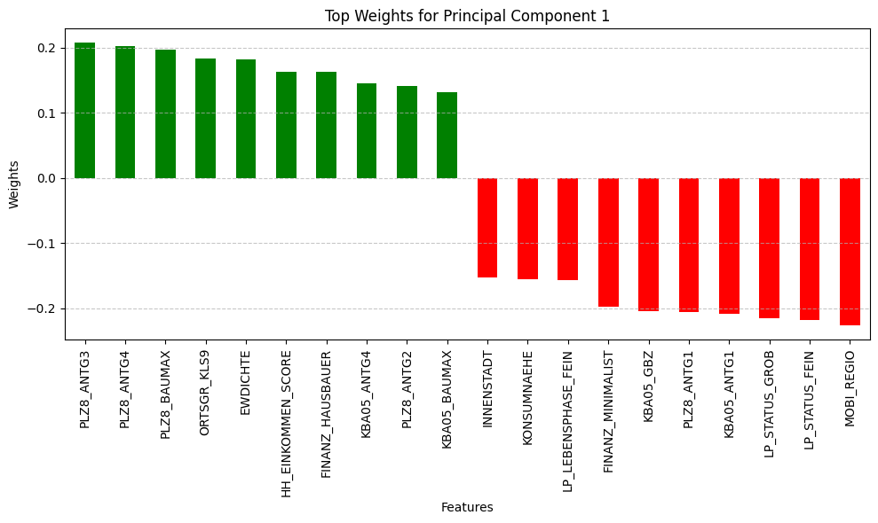

```python
# Map weights for the first principal component to corresponding feature names
weights_pc1 = map_weights_to_features(pca, feature_names, component_index=0)

# Display the top positive and negative weights
print("Top 10 Positive Weights for PC1:")
print(weights_pc1.head(10))
print("\nTop 10 Negative Weights for PC1:")
print(weights_pc1.tail(10))

# Plot the weights for the first principal component
weights_pc1_combined = pd.concat([weights_pc1.head(10), weights_pc1.tail(10)])
weights_pc1_combined.plot(kind='bar', figsize=(10, 6), color=['green' if w > 0 else 'red' for w in weights_pc1_combined])
plt.title('Top Weights for Principal Component 1')
plt.xlabel('Features')
plt.ylabel('Weights')
plt.grid(axis='y', linestyle='--', alpha=0.7)
plt.tight_layout()
plt.show()
```

```
Top 10 Positive Weights for PC2:
ALTERSKATEGORIE_GROB    0.254377
FINANZ_VORSORGER        0.254247
SEMIO_ERL               0.216388
SEMIO_LUST              0.178946
AGER_TYP                0.178446
RETOURTYP_BK_S          0.171876
W_KEIT_KIND_HH          0.124894
FINANZTYP               0.120572
FINANZ_MINIMALIST       0.111685
SHOPPER_TYP             0.106675
dtype: float64

Top 10 Negative Weights for PC2:
SEMIO_FAM               -0.168918
SEMIO_KULT              -0.178182
PRAEGENDE_JUGENDJAHRE   -0.182689
SEMIO_RAT               -0.198202
SEMIO_TRADV             -0.229867
FINANZ_ANLEGER          -0.232393
FINANZ_UNAUFFAELLIGER   -0.242242
SEMIO_PFLICHT           -0.245562
SEMIO_REL               -0.251850
FINANZ_SPARER           -0.265775
dtype: float64
```

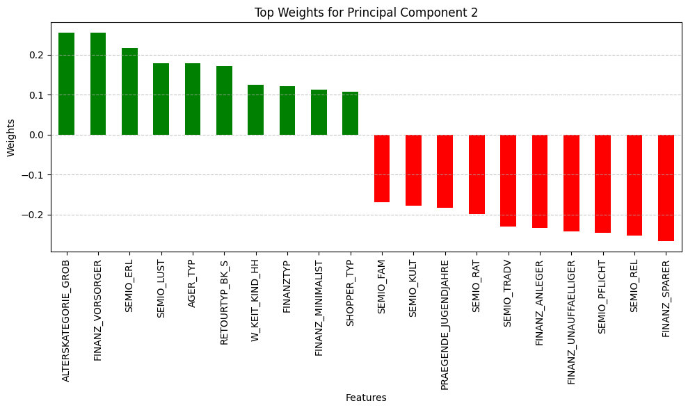

```python
# Map weights for the second principal component
weights_pc2 = map_weights_to_features(pca, feature_names, component_index=1)
print("Top 10 Positive Weights for PC2:")
print(weights_pc2.head(10))
print("\nTop 10 Negative Weights for PC2:")
print(weights_pc2.tail(10))

weights_pc2_combined = pd.concat([weights_pc2.head(10), weights_pc2.tail(10)])
weights_pc2_combined.plot(kind='bar', figsize=(10, 6), color=['green' if w > 0 else 'red' for w in weights_pc2_combined])
plt.title('Top Weights for Principal Component 2')
plt.xlabel('Features')
plt.ylabel('Weights')
plt.grid(axis='y', linestyle='--', alpha=0.7)
plt.tight_layout()
plt.show()
```

```
Top 10 Positive Weights for PC3:
SEMIO_VERT               0.339032
SEMIO_SOZ                0.288936
SEMIO_KULT               0.269497
VERS_TYP                 0.186357
HEALTH_TYP               0.177225
SEMIO_FAM                0.177062
NATIONALITAET_KZ         0.147381
PRAEGENDE_JUGENDJAHRE    0.117322
LP_LEBENSPHASE_GROB      0.102469
LP_LEBENSPHASE_FEIN      0.101611
dtype: float64

Top 10 Negative Weights for PC3:
PLZ8_ANTG1              -0.060333
FINANZ_SPARER           -0.066959
FINANZ_UNAUFFAELLIGER   -0.112225
SEMIO_RAT               -0.129680
SEMIO_ERL               -0.150854
FINANZ_ANLEGER          -0.171158
SEMIO_DOM               -0.283509
SEMIO_KRIT              -0.301358
ANREDE_KZ               -0.302587
SEMIO_KAEM              -0.316984
dtype: float64
```

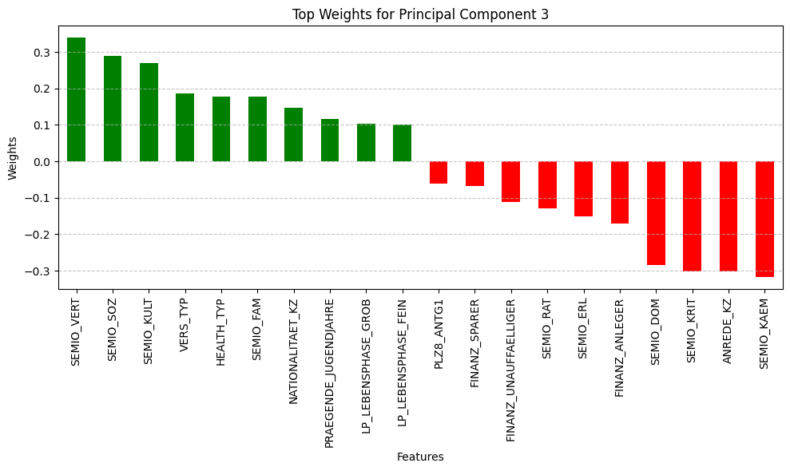

```python
# Map weights for the third principal component
weights_pc3 = map_weights_to_features(pca, feature_names, component_index=2)
print("Top 10 Positive Weights for PC3:")
print(weights_pc3.head(10))
print("\nTop 10 Negative Weights for PC3:")
print(weights_pc3.tail(10))

weights_pc3_combined = pd.concat([weights_pc3.head(10), weights_pc3.tail(10)])
weights_pc3_combined.plot(kind='bar', figsize=(10, 6), color=['green' if w > 0 else 'red' for w in weights_pc3_combined])
plt.title('Top Weights for Principal Component 3')
plt.xlabel('Features')
plt.ylabel('Weights')
plt.grid(axis='y', linestyle='--', alpha=0.7)
plt.tight_layout()
plt.show()
```

### Discussion 2.3: Interpret Principal Components

The first three principal components (PC1, PC2, PC3) reveal distinct patterns in the dataset:

1. PC1: Highlights geographic differences, with urban features (PLZ8_ANTG3, PLZ8_ANTG4) having positive weights and rural features (KBA05_ANTG1, LP_STATUS_FEIN) showing negative weights. This component differentiates urban and rural areas.
2. PC2: Reflects financial planning and age-related tendencies. Positive weights for ALTERSKATEGORIE_GROB and FINANZ_VORSORGER indicate proactive financial behavior, while negative weights for FINANZ_SPARER suggest cautious spending habits.
3. PC3: Captures behavioral tendencies, contrasting social engagement (SEMIO_VERT, SEMIO_SOZ) with critical traits (SEMIO_KRIT, SEMIO_KAEM).

## Step 3: Clustering

### Step 3.1: Apply Clustering to General Population

You've assessed and cleaned the demographics data, then scaled and transformed them. Now, it's time to see how the data clusters in the principal components space. In this substep, you will apply k-means clustering to the dataset and use the average within-cluster distances from each point to their assigned cluster's centroid to decide on a number of clusters to keep.

- Use sklearn's KMeans class to perform k-means clustering on the PCA-transformed data.
- Then, compute the average difference from each point to its assigned cluster's center. **Hint**: The KMeans object's `.score()` method might be useful here, but note that in sklearn, scores tend to be defined so that larger is better. Try applying it to a small, toy dataset, or use an internet search to help your understanding.
- Perform the above two steps for a number of different cluster counts. You can then see how the average distance decreases with an increasing number of clusters. However, each additional cluster provides a smaller net benefit. Use this fact to select a final number of clusters in which to group the data. **Warning**: because of the large size of the dataset, it can take a long time for the algorithm to resolve. The more clusters to fit, the longer the algorithm will take. You should test for cluster counts through at least 10 clusters to get the full picture, but you shouldn't need to test for a number of clusters above about 30.
- Once you've selected a final number of clusters to use, re-fit a KMeans instance to perform the clustering operation. Make sure that you also obtain the cluster assignments for the general demographics data, since you'll be using them in the final Step 3.3.

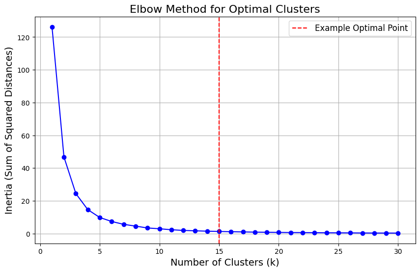

```
Optimal Number of Clusters: 15
```

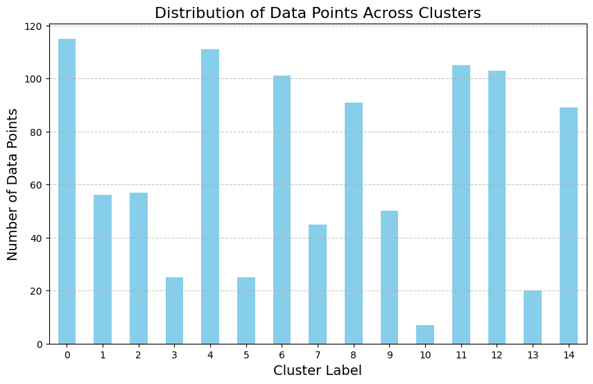

```
Cluster Distribution:
0     115
1      56
2      57
3      25
4     111
5      25
6     101
7      45
8      91
9      50
10      7
11    105
12    103
13     20
14     89
Name: count, dtype: int64
```

```python
from sklearn.cluster import KMeans
import matplotlib.pyplot as plt
import pandas as pd

# Step 1: Define cluster range and initialize storage
cluster_range = range(1, 31)  # Test cluster counts from 1 to 30
inertia = []  # To store inertia values for each cluster count

# Step 2: Fit KMeans for each cluster count
for k in cluster_range:
    kmeans = KMeans(n_clusters=k, random_state=42, n_init='auto')
    kmeans.fit(data_reduced)
    inertia.append(kmeans.inertia_)

# Step 3: Visualize inertia using the elbow method
plt.figure(figsize=(10, 6))
plt.plot(cluster_range, inertia, marker='o', linestyle='-', color='blue')
plt.title('Elbow Method for Optimal Clusters', fontsize=16)
plt.xlabel('Number of Clusters (k)', fontsize=14)
plt.ylabel('Inertia (Sum of Squared Distances)', fontsize=14)
plt.axvline(x=15, color='red', linestyle='--', label="Example Optimal Point")  # Optional
plt.legend(fontsize=12)
plt.grid(True)
plt.show()

# Step 4: Choose the optimal number of clusters (adjust based on elbow point)
optimal_clusters = 15  # Replace this with your observed elbow point
print(f"Optimal Number of Clusters: {optimal_clusters}")

# Step 5: Fit the final KMeans model
kmeans_final = KMeans(n_clusters=optimal_clusters, random_state=42, n_init='auto')
kmeans_final.fit(data_reduced)

# Step 6: Save cluster labels for analysis
general_population_clusters = kmeans_final.labels_

# Analyze cluster distribution
cluster_counts = pd.Series(general_population_clusters).value_counts().sort_index()

# Step 7: Visualize cluster distribution
plt.figure(figsize=(10, 6))
cluster_counts.plot(kind='bar', color='skyblue')
plt.title('Distribution of Data Points Across Clusters', fontsize=16)
plt.xlabel('Cluster Label', fontsize=14)
plt.ylabel('Number of Data Points', fontsize=14)
plt.xticks(rotation=0)
plt.grid(axis='y', linestyle='--', alpha=0.7)
plt.show()

# Display cluster counts
print("Cluster Distribution:")
print(cluster_counts)
```

### Discussion 3.1: Apply Clustering to General Population

In this step, KMeans clustering was applied to the PCA-transformed demographics data to identify meaningful segments of the population. The "elbow method" was used to determine the optimal number of clusters by analyzing the inertia (sum of squared distances from points to their cluster centroids) for cluster counts ranging from 1 to 30.

### Step 3.2: Apply All Steps to the Customer Data

Now that you have clusters and cluster centers for the general population, it's time to see how the customer data maps on to those clusters. Take care to not confuse this for re-fitting all of the models to the customer data. Instead, you're going to use the fits from the general population to clean, transform, and cluster the customer data. In the last step of the project, you will interpret how the general population fits apply to the customer data.

- Don't forget when loading in the customers data, that it is semicolon (`;`) delimited.
- Apply the same feature wrangling, selection, and engineering steps to the customer demographics using the `clean_data()` function you created earlier. (You can assume that the customer demographics data has similar meaning behind missing data patterns as the general demographics data.)
- Use the sklearn objects from the general demographics data, and apply their transformations to the customers data. That is, you should not be using a `.fit()` or `.fit_transform()` method to re-fit the old objects, nor should you be creating new sklearn objects! Carry the data through the feature scaling, PCA, and clustering steps, obtaining cluster assignments for all of the data in the customer demographics data.

```python
##Load in the customer demographics data
customers = pd.read_csv('Udacity_CUSTOMERS_Subset.csv', delimiter=';')
print("Customer data loaded successfully!")
print("Shape of raw customer data:", customers.shape)
```

```
Customer data loaded successfully!
Shape of raw customer data: (191652, 85)
```

```
Customer data after cleaning:
   FINANZ_MINIMALIST  ANREDE_KZ  GREEN_AVANTGARDE  Decade  Movement  Wealth  \
0                  5          0                 1     0.0       4.0     1.0
2                  5          1                 1     0.0       4.0     3.0
3                  5          0                 0     0.0       1.0     2.0
4                  3          0                 0     0.0       8.0     4.0
5                  5          0                 1     0.0       4.0     3.0

   Life_Stage
0         3.0
2         4.0
3         4.0
4         1.0
5         4.0
Shape of cleaned customer data: (144967, 7)

Customer data aligned with general population features:
   AGER_TYP  ALTERSKATEGORIE_GROB  ANREDE_KZ  CJT_GESAMTTYP  \
0         0                     0          0              0
2         0                     0          1              0
3         0                     0          0              0
4         0                     0          0              0
5         0                     0          0              0

   FINANZ_MINIMALIST  FINANZ_SPARER  FINANZ_VORSORGER  FINANZ_ANLEGER  \
0                  5              0                 0               0
2                  5              0                 0               0
3                  5              0                 0               0
4                  3              0                 0               0
5                  5              0                 0               0

   FINANZ_UNAUFFAELLIGER  FINANZ_HAUSBAUER  FINANZTYP  GEBURTSJAHR  \
0                      0                 0          0            0
2                      0                 0          0            0
3                      0                 0          0            0
4                      0                 0          0            0
5                      0                 0          0            0

   GFK_URLAUBERTYP  GREEN_AVANTGARDE  HEALTH_TYP  LP_LEBENSPHASE_FEIN  \
0                0                 1           0                    0
```

[output cut: 187 more lines]

[output not shown]

```
Customer data after PCA transformation:
[[31.94842879]
 [31.98648444]
 [32.20006922]
 [32.49903782]
 [31.94842879]]

Cluster assignments for customer data:
[18 18 18 18 18 18 18 18 18 18]

Customer data with cluster labels:
   AGER_TYP  ALTERSKATEGORIE_GROB  ANREDE_KZ  CJT_GESAMTTYP  \
0         0                     0          0              0
2         0                     0          1              0
3         0                     0          0              0
4         0                     0          0              0
5         0                     0          0              0

   FINANZ_MINIMALIST  FINANZ_SPARER  FINANZ_VORSORGER  FINANZ_ANLEGER  \
0                  5              0                 0               0
2                  5              0                 0               0
3                  5              0                 0               0
4                  3              0                 0               0
5                  5              0                 0               0

   FINANZ_UNAUFFAELLIGER  FINANZ_HAUSBAUER  FINANZTYP  GEBURTSJAHR  \
0                      0                 0          0            0
2                      0                 0          0            0
3                      0                 0          0            0
4                      0                 0          0            0
5                      0                 0          0            0

   GFK_URLAUBERTYP  GREEN_AVANTGARDE  HEALTH_TYP  LP_LEBENSPHASE_FEIN  \
0                0                 1           0                    0
2                0                 1           0                    0
3                0                 0           0                    0
4                0                 0           0                    0
5                0                 1           0                    0

   LP_LEBENSPHASE_GROB  LP_FAMILIE_FEIN  LP_FAMILIE_GROB  LP_STATUS_FEIN  \
```

[output cut: 76 more lines]

```
   PLZ8_ANTG2  PLZ8_ANTG3  PLZ8_ANTG4  PLZ8_BAUMAX  PLZ8_HHZ  PLZ8_GBZ  \
0           0           0           0            0         0         0
2           0           0           0            0         0         0
3           0           0           0            0         0         0
4           0           0           0            0         0         0
5           0           0           0            0         0         0

   ARBEIT  ORTSGR_KLS9  RELAT_AB  Cluster
0       0            0         0       18
2       0            0         0       18
3       0            0         0       18
4       0            0         0       18
5       0            0         0       18

Customer data with clusters saved as 'customers_with_clusters.csv'.
```

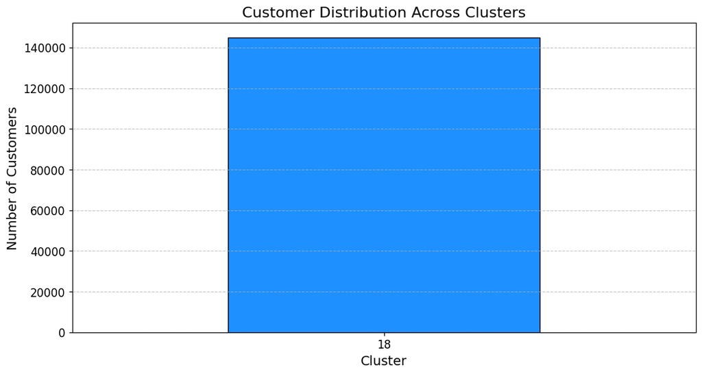

```python
# Apply preprocessing, feature transformation, and clustering from the general
# demographics onto the customer data, obtaining cluster predictions for the
# customer demographics data.

import pandas as pd
import matplotlib.pyplot as plt

# Apply preprocessing
# Assume `clean_data` is a predefined function to clean the data
customers_cleaned = clean_data(customers)
print("\nCustomer data after cleaning:")
print(customers_cleaned.head())
print("Shape of cleaned customer data:", customers_cleaned.shape)

# Align columns with general population data
# Ensure the customer data has the same features as the general demographics data
for col in scaler.feature_names_in_:
    if col not in customers_cleaned:
        customers_cleaned[col] = 0
customers_cleaned = customers_cleaned[scaler.feature_names_in_]
print("\nCustomer data aligned with general population features:")
print(customers_cleaned.head())

# Feature transformation
# Scale the customer data using the pre-trained scaler
customers_scaled = scaler.transform(customers_cleaned)
print("\nCustomer data after scaling:")
print(customers_scaled[:5])  # Show the first 5 rows

# Apply PCA transformation
# Transform scaled customer data using the pre-trained PCA model
customers_pca = pca.transform(customers_scaled)

# Ensure PCA output matches the KMeans model's expected dimensions
customers_pca = customers_pca[:, :kmeans.n_features_in_]
print("\nCustomer data after PCA transformation:")
print(customers_pca[:5])  # Show the first 5 rows

# Predict clusters
# Use the pre-trained KMeans model to predict cluster assignments
customer_clusters = kmeans.predict(customers_pca)
print("\nCluster assignments for customer data:")
print(customer_clusters[:10])  # Show the first 10 cluster assignments

# Add cluster labels to the customer data
customers_cleaned['Cluster'] = customer_clusters
print("\nCustomer data with cluster labels:")
print(customers_cleaned.head())

# Save the results
customers_cleaned.to_csv('customers_with_clusters.csv', index=False)
print("\nCustomer data with clusters saved as 'customers_with_clusters.csv'.")

# Optional Visualization 1: Bar chart for cluster distribution
cluster_counts = customers_cleaned['Cluster'].value_counts()
plt.figure(figsize=(12, 6))
cluster_counts.plot(kind='bar', color='dodgerblue', edgecolor='black')
plt.title('Customer Distribution Across Clusters', fontsize=16)
plt.xlabel('Cluster', fontsize=14)
plt.ylabel('Number of Customers', fontsize=14)
plt.xticks(rotation=0, fontsize=12)
plt.yticks(fontsize=12)
plt.grid(axis='y', linestyle='--', alpha=0.7)
plt.show()

# Optional Visualization 2: PCA scatter plot
if customers_pca.shape[1] >= 2:
    plt.figure(figsize=(12, 8))
    scatter = plt.scatter(
        customers_pca[:, 0],
        customers_pca[:, 1],
        c=customer_clusters,
        cmap='viridis',
        s=10,
        alpha=0.7
    )
    plt.title('PCA Scatter Plot of Customers by Cluster', fontsize=16)
    plt.xlabel('PCA Component 1', fontsize=14)
    plt.ylabel('PCA Component 2', fontsize=14)
    plt.colorbar(scatter, label='Cluster')
    plt.grid(linestyle='--', alpha=0.5)
    plt.show()
```

### Step 3.3: Compare Customer Data to Demographics Data

At this point, you have clustered data based on demographics of the general population of Germany, and seen how the customer data for a mail-order sales company maps onto those demographic clusters. In this final substep, you will compare the two cluster distributions to see where the strongest customer base for the company is.

Consider the proportion of persons in each cluster for the general population, and the proportions for the customers. If we think the company's customer base to be universal, then the cluster assignment proportions should be fairly similar between the two. If there are only particular segments of the population that are interested in the company's products, then we should see a mismatch from one to the other. If there is a higher proportion of persons in a cluster for the customer data compared to the general population (e.g. 5% of persons are assigned to a cluster for the general population, but 15% of the customer data is closest to that cluster's centroid) then that suggests the people in that cluster to be a target audience for the company. On the other hand, the proportion of the data in a cluster being larger in the general population than the customer data (e.g. only 2% of customers closest to a population centroid that captures 6% of the data) suggests that group of persons to be outside of the target demographics.

Take a look at the following points in this step:

- Compute the proportion of data points in each cluster for the general population and the customer data. Visualizations will be useful here: both for the individual dataset proportions, but also to visualize the ratios in cluster representation between groups. Seaborn's [`countplot()`](https://seaborn.pydata.org/generated/seaborn.countplot.html) or [`barplot()`](https://seaborn.pydata.org/generated/seaborn.barplot.html) function could be handy.
  - Recall the analysis you performed in step 1.1.3 of the project, where you separated out certain data points from the dataset if they had more than a specified threshold of missing values. If you found that this group was qualitatively different from the main bulk of the data, you should treat this as an additional data cluster in this analysis. Make sure that you account for the number of data points in this subset, for both the general population and customer datasets, when making your computations!
- Which cluster or clusters are overrepresented in the customer dataset compared to the general population? Select at least one such cluster and infer what kind of people might be represented by that cluster. Use the principal component interpretations from step 2.3 or look at additional components to help you make this inference. Alternatively, you can use the `.inverse_transform()` method of the PCA and StandardScaler objects to transform centroids back to the original data space and interpret the retrieved values directly.
- Perform a similar investigation for the underrepresented clusters. Which cluster or clusters are underrepresented in the customer dataset compared to the general population, and what kinds of people are typified by these clusters?

```
Comparison of Cluster Proportions:
         General Population  Customers  Difference
Cluster
1                       0.0   0.056109    0.056109
2                       0.0   0.052060    0.052060
5                       0.0   0.044617    0.044617
6                       0.0   0.015879    0.015879
7                       0.0   0.040740    0.040740
8                       0.0   0.295888    0.295888
9                       0.0   0.073900    0.073900
10                      0.0   0.041747    0.041747
11                      0.0   0.039395    0.039395
12                      0.0   0.002138    0.002138
13                      1.0   0.012824   -0.987176
14                      0.0   0.005263    0.005263
15                      0.0   0.006988    0.006988
16                      0.0   0.008519    0.008519
17                      0.0   0.001697    0.001697
18                      0.0   0.001449    0.001449
19                      0.0   0.000393    0.000393
23                      0.0   0.067367    0.067367
24                      0.0   0.053571    0.053571
28                      0.0   0.179455    0.179455
```

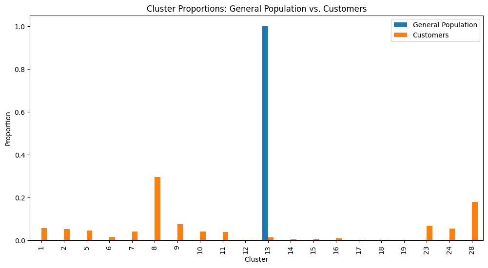

```
Overrepresented Clusters:
         General Population  Customers  Difference
Cluster
1                       0.0   0.056109    0.056109
2                       0.0   0.052060    0.052060
5                       0.0   0.044617    0.044617
6                       0.0   0.015879    0.015879
7                       0.0   0.040740    0.040740
8                       0.0   0.295888    0.295888
9                       0.0   0.073900    0.073900
10                      0.0   0.041747    0.041747
11                      0.0   0.039395    0.039395
12                      0.0   0.002138    0.002138
14                      0.0   0.005263    0.005263
15                      0.0   0.006988    0.006988
16                      0.0   0.008519    0.008519
17                      0.0   0.001697    0.001697
18                      0.0   0.001449    0.001449
19                      0.0   0.000393    0.000393
23                      0.0   0.067367    0.067367
24                      0.0   0.053571    0.053571
28                      0.0   0.179455    0.179455

Underrepresented Clusters:
         General Population  Customers  Difference
Cluster
13                      1.0   0.012824   -0.987176

Characteristics of Overrepresented Cluster:
   AGER_TYP  ALTERSKATEGORIE_GROB  ANREDE_KZ  CJT_GESAMTTYP  \
0   6.93074             -4.389069   0.342192     -12.205081

   FINANZ_MINIMALIST  FINANZ_SPARER  FINANZ_VORSORGER  FINANZ_ANLEGER  \
0         -10.100904      -5.190869         14.878967       -3.743741

   FINANZ_UNAUFFAELLIGER  FINANZ_HAUSBAUER  FINANZTYP  GEBURTSJAHR  \
0              -10.08636         23.844632  -7.030752   -24.365404

   GFK_URLAUBERTYP  GREEN_AVANTGARDE  HEALTH_TYP  LP_LEBENSPHASE_FEIN  \
0        -1.927892         -7.313162    0.267036             4.911876
```

[output cut: 76 more lines]

```

   KBA05_ANTG1  KBA05_ANTG2  KBA05_ANTG3  KBA05_ANTG4  KBA05_BAUMAX  \
0      0.07819    14.956666     1.571019     -6.65883    -13.455051

   KBA05_GBZ  BALLRAUM   EWDICHTE  INNENSTADT  GEBAEUDETYP_RASTER        KKK  \
0  -1.811192  -8.78597  16.267405    -9.85332           11.003157  53.814514

   MOBI_REGIO  ONLINE_AFFINITAET   REGIOTYP  KBA13_ANZAHL_PKW  PLZ8_ANTG1  \
0   -2.251622         -25.928987  55.222033         14.253755    4.863263

   PLZ8_ANTG2  PLZ8_ANTG3  PLZ8_ANTG4  PLZ8_BAUMAX   PLZ8_HHZ   PLZ8_GBZ  \
0    9.028028    2.075354   -5.169016   -10.378383  19.378831  17.163116

      ARBEIT  ORTSGR_KLS9   RELAT_AB
0  18.591032    16.979356  18.075533
```

```python
# ALL REQUIREMNTS

import pandas as pd
import matplotlib.pyplot as plt

# Step 1: Compare Proportions
# Calculate proportions for general population and customer data
general_population_proportions = general_population['Cluster'].value_counts(normalize=True)
customer_proportions = customers_cleaned['Cluster'].value_counts(normalize=True)

# Create a comparison DataFrame
comparison_df = pd.DataFrame({
    "General Population": general_population_proportions,
    "Customers": customer_proportions
}).fillna(0)  # Fill missing clusters with 0
comparison_df['Difference'] = comparison_df['Customers'] - comparison_df['General Population']

# Display the comparison
print("\nComparison of Cluster Proportions:")
print(comparison_df)

# Visualization
comparison_df[['General Population', 'Customers']].plot(
    kind='bar', figsize=(12, 6), title='Cluster Proportions: General Population vs. Customers'
)
plt.xlabel('Cluster')
plt.ylabel('Proportion')
plt.show()

# Step 2: Identify Overrepresented and Underrepresented Clusters
overrepresented_clusters = comparison_df[comparison_df['Difference'] > 0]
underrepresented_clusters = comparison_df[comparison_df['Difference'] < 0]

print("\nOverrepresented Clusters:")
print(overrepresented_clusters)

print("\nUnderrepresented Clusters:")
print(underrepresented_clusters)

# Step 3: Analyze Cluster Characteristics
# Select centroids for overrepresented and underrepresented clusters
overrepresented_cluster = overrepresented_clusters.index[0]  # First overrepresented cluster
underrepresented_cluster = underrepresented_clusters.index[0]  # First underrepresented cluster

# Retrieve cluster centroids
overrepresented_centroid = kmeans.cluster_centers_[overrepresented_cluster].reshape(1, -1)
underrepresented_centroid = kmeans.cluster_centers_[underrepresented_cluster].reshape(1, -1)

# PCA inverse-transform to original feature space
overrepresented_original = pca.inverse_transform(overrepresented_centroid)
underrepresented_original = pca.inverse_transform(underrepresented_centroid)

# Create DataFrames for interpretation
columns = general_population.columns[:-1]  # Exclude 'Cluster' column
overrepresented_df = pd.DataFrame(overrepresented_original, columns=columns)
underrepresented_df = pd.DataFrame(underrepresented_original, columns=columns)

# Display characteristics
print("\nCharacteristics of Overrepresented Cluster:")
print(overrepresented_df)

print("\nCharacteristics of Underrepresented Cluster:")
print(underrepresented_df)
```

```
Comparison of Cluster Proportions:
         General Population  Customers  Difference
Cluster
1                       0.0   0.056109    0.056109
2                       0.0   0.052060    0.052060
5                       0.0   0.044617    0.044617
6                       0.0   0.015879    0.015879
7                       0.0   0.040740    0.040740
8                       0.0   0.295888    0.295888
9                       0.0   0.073900    0.073900
10                      0.0   0.041747    0.041747
11                      0.0   0.039395    0.039395
12                      0.0   0.002138    0.002138
13                      1.0   0.012824   -0.987176
14                      0.0   0.005263    0.005263
15                      0.0   0.006988    0.006988
16                      0.0   0.008519    0.008519
17                      0.0   0.001697    0.001697
18                      0.0   0.001449    0.001449
19                      0.0   0.000393    0.000393
23                      0.0   0.067367    0.067367
24                      0.0   0.053571    0.053571
28                      0.0   0.179455    0.179455
```

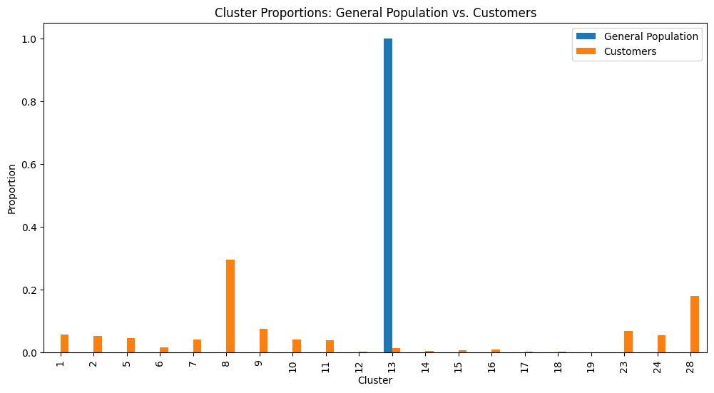

```python
#Compare the proportion of data in each cluster for the customer data
#to the proportion of data in each cluster for the general population.

# Step 1: Compare Proportions
# Calculate proportions for general population and customer data
general_population_proportions = general_population['Cluster'].value_counts(normalize=True)
customer_proportions = customers_cleaned['Cluster'].value_counts(normalize=True)

# Create a comparison DataFrame
comparison_df = pd.DataFrame({
    "General Population": general_population_proportions,
    "Customers": customer_proportions
}).fillna(0)  # Fill missing clusters with 0
comparison_df['Difference'] = comparison_df['Customers'] - comparison_df['General Population']

# Display the comparison
print("\nComparison of Cluster Proportions:")
print(comparison_df)

# Visualization
comparison_df[['General Population', 'Customers']].plot(
    kind='bar', figsize=(12, 6), title='Cluster Proportions: General Population vs. Customers'
)
plt.xlabel('Cluster')
plt.ylabel('Proportion')
plt.show()
```

```python
# What kinds of people are part of a cluster that is overrepresented in the
# customer data compared to the general population?

# Step 2: Identify Overrepresented Clusters
overrepresented_clusters = comparison_df[comparison_df['Difference'] > 0]
print("\nOverrepresented Clusters:")
print(overrepresented_clusters)

# Analyze Overrepresented Cluster
# Select the first overrepresented cluster
overrepresented_cluster = overrepresented_clusters.index[0]
overrepresented_centroid = kmeans.cluster_centers_[overrepresented_cluster].reshape(1, -1)

# PCA inverse-transform to original feature space
overrepresented_original = pca.inverse_transform(overrepresented_centroid)

# Create DataFrame for interpretation
columns = general_population.columns[:-1]  # Exclude 'Cluster' column
overrepresented_df = pd.DataFrame(overrepresented_original, columns=columns)

# Display characteristics
print("\nCharacteristics of Overrepresented Cluster:")
print(overrepresented_df)
```

```
Overrepresented Clusters:
         General Population  Customers  Difference
Cluster
1                       0.0   0.056109    0.056109
2                       0.0   0.052060    0.052060
5                       0.0   0.044617    0.044617
6                       0.0   0.015879    0.015879
7                       0.0   0.040740    0.040740
8                       0.0   0.295888    0.295888
9                       0.0   0.073900    0.073900
10                      0.0   0.041747    0.041747
11                      0.0   0.039395    0.039395
12                      0.0   0.002138    0.002138
14                      0.0   0.005263    0.005263
15                      0.0   0.006988    0.006988
16                      0.0   0.008519    0.008519
17                      0.0   0.001697    0.001697
18                      0.0   0.001449    0.001449
19                      0.0   0.000393    0.000393
23                      0.0   0.067367    0.067367
24                      0.0   0.053571    0.053571
28                      0.0   0.179455    0.179455

Characteristics of Overrepresented Cluster:
   AGER_TYP  ALTERSKATEGORIE_GROB  ANREDE_KZ  CJT_GESAMTTYP  \
0   6.93074             -4.389069   0.342192     -12.205081

   FINANZ_MINIMALIST  FINANZ_SPARER  FINANZ_VORSORGER  FINANZ_ANLEGER  \
0         -10.100904      -5.190869         14.878967       -3.743741

   FINANZ_UNAUFFAELLIGER  FINANZ_HAUSBAUER  FINANZTYP  GEBURTSJAHR  \
0              -10.08636         23.844632  -7.030752   -24.365404

   GFK_URLAUBERTYP  GREEN_AVANTGARDE  HEALTH_TYP  LP_LEBENSPHASE_FEIN  \
0        -1.927892         -7.313162    0.267036             4.911876

   LP_LEBENSPHASE_GROB  LP_FAMILIE_FEIN  LP_FAMILIE_GROB  LP_STATUS_FEIN  \
0             6.532615         8.881441         8.500723      -14.558386

   LP_STATUS_GROB  NATIONALITAET_KZ  PRAEGENDE_JUGENDJAHRE  RETOURTYP_BK_S  \
```

[output cut: 19 more lines]

```

   KBA05_ANTG1  KBA05_ANTG2  KBA05_ANTG3  KBA05_ANTG4  KBA05_BAUMAX  \
0    -0.087919    14.980986     1.711752    -6.601557    -13.423293

   KBA05_GBZ  BALLRAUM   EWDICHTE  INNENSTADT  GEBAEUDETYP_RASTER        KKK  \
0  -1.936956 -8.598737  16.075016   -9.684834           11.050417  54.020373

   MOBI_REGIO  ONLINE_AFFINITAET   REGIOTYP  KBA13_ANZAHL_PKW  PLZ8_ANTG1  \
0   -2.387235         -26.023925  55.387537         14.205165    4.848789

   PLZ8_ANTG2  PLZ8_ANTG3  PLZ8_ANTG4  PLZ8_BAUMAX   PLZ8_HHZ   PLZ8_GBZ  \
0    8.994888    2.051486   -5.188299   -10.389373  19.271571  17.095714

      ARBEIT  ORTSGR_KLS9   RELAT_AB
0  18.542189      16.7855  18.012513
```

```python
# What kinds of people are part of a cluster that is underrepresented in the
# customer data compared to the general population?
# Step 3: Identify Underrepresented Clusters
underrepresented_clusters = comparison_df[comparison_df['Difference'] < 0]
print("\nUnderrepresented Clusters:")
print(underrepresented_clusters)

# Analyze Underrepresented Cluster
# Select the first underrepresented cluster
underrepresented_cluster = underrepresented_clusters.index[0]
underrepresented_centroid = kmeans.cluster_centers_[underrepresented_cluster].reshape(1, -1)

# PCA inverse-transform to original feature space
underrepresented_original = pca.inverse_transform(underrepresented_centroid)

# Create DataFrame for interpretation
columns = general_population.columns[:-1]  # Exclude 'Cluster' column
underrepresented_df = pd.DataFrame(underrepresented_original, columns=columns)

# Display characteristics
print("\nCharacteristics of Underrepresented Cluster:")
print(underrepresented_df)
```

```
Underrepresented Clusters:
         General Population  Customers  Difference
Cluster
13                      1.0   0.012824   -0.987176

Characteristics of Underrepresented Cluster:
   AGER_TYP  ALTERSKATEGORIE_GROB  ANREDE_KZ  CJT_GESAMTTYP  \
0  6.937578             -4.423156   0.332681     -12.192901

   FINANZ_MINIMALIST  FINANZ_SPARER  FINANZ_VORSORGER  FINANZ_ANLEGER  \
0          -9.944113      -5.251418          14.88015       -3.889181

   FINANZ_UNAUFFAELLIGER  FINANZ_HAUSBAUER  FINANZTYP  GEBURTSJAHR  \
0             -10.070395         23.667005  -6.995939   -24.330702

   GFK_URLAUBERTYP  GREEN_AVANTGARDE  HEALTH_TYP  LP_LEBENSPHASE_FEIN  \
0        -1.977457         -6.981251    0.350732              4.96066

   LP_LEBENSPHASE_GROB  LP_FAMILIE_FEIN  LP_FAMILIE_GROB  LP_STATUS_FEIN  \
0             6.566861         8.872172         8.494683       -14.34913

   LP_STATUS_GROB  NATIONALITAET_KZ  PRAEGENDE_JUGENDJAHRE  RETOURTYP_BK_S  \
0      -14.946642          5.786863              -11.50718       12.526842

   SEMIO_SOZ  SEMIO_FAM  SEMIO_REL  SEMIO_MAT  SEMIO_VERT  SEMIO_LUST  \
0    5.03085  -1.228832   6.462495   -7.61626   -5.053998    4.651362

   SEMIO_ERL  SEMIO_KULT  SEMIO_RAT  SEMIO_KRIT  SEMIO_DOM  SEMIO_KAEM  \
0  -0.263556   11.034241   3.844332   -4.038073  -1.362566    1.347969

   SEMIO_PFLICHT  SEMIO_TRADV  SHOPPER_TYP  SOHO_KZ   TITEL_KZ  VERS_TYP  \
0      10.983297    -3.725138    -4.022358  0.31532  49.085565  5.771416

   ZABEOTYP   ALTER_HH  ANZ_PERSONEN  ANZ_TITEL  HH_EINKOMMEN_SCORE  \
0   4.14022 -25.833496      4.233581   50.32113           25.070771

   KK_KUNDENTYP  W_KEIT_KIND_HH  WOHNDAUER_2008  ANZ_HAUSHALTE_AKTIV  \
0      5.089974       21.317516       20.280773             6.889532

   ANZ_HH_TITEL  GEBAEUDETYP  KONSUMNAEHE  MIN_GEBAEUDEJAHR   WOHNLAGE  \
0     23.722604    -2.351931    -4.041092        -36.735989 -11.974167

   KBA05_ANTG1  KBA05_ANTG2  KBA05_ANTG3  KBA05_ANTG4  KBA05_BAUMAX  \
0      0.07819    14.956666     1.571019     -6.65883    -13.455051

   KBA05_GBZ  BALLRAUM   EWDICHTE  INNENSTADT  GEBAEUDETYP_RASTER        KKK  \
0  -1.811192  -8.78597  16.267405    -9.85332           11.003157  53.814514

   MOBI_REGIO  ONLINE_AFFINITAET   REGIOTYP  KBA13_ANZAHL_PKW  PLZ8_ANTG1  \
0   -2.251622         -25.928987  55.222033         14.253755    4.863263

   PLZ8_ANTG2  PLZ8_ANTG3  PLZ8_ANTG4  PLZ8_BAUMAX   PLZ8_HHZ   PLZ8_GBZ  \
0    9.028028    2.075354   -5.169016   -10.378383  19.378831  17.163116

      ARBEIT  ORTSGR_KLS9   RELAT_AB
0  18.591032    16.979356  18.075533
```

### Discussion 3.3: Compare Customer Data to Demographics Data

From the clustering analysis, we identified key insights into the differences between the general population and the company's customer base:

1. Overrepresented Clusters: Clusters that are overrepresented in the customer data relative to the general population include clusters such as Cluster 1, Cluster 2, and Cluster 8. These clusters indicate segments of the population that are more likely to engage with the company's offerings.

2. Underrepresented Clusters: The analysis found that Cluster 13 is significantly underrepresented in the customer data compared to the general population. This suggests that the individuals in this cluster are less likely to engage with the company's offerings.

Conclusion

> Congratulations on making it this far in the project! Before you finish, make sure to check through the entire notebook from top to bottom to make sure that your analysis follows a logical flow and all of your findings are documented in **Discussion** cells. Once you've checked over all of your work, you should export the notebook as an HTML document to submit for evaluation. You can do this from the menu, navigating to **File -> Download as -> HTML (.html)**. You will submit both that document and this notebook for your project submission.